# BMI 与抑郁症状的复杂双向关系 — 高级分析

多种建模策略探索复杂关系（最终修订版）

Zhiliang Lin

2026-04-06

# 1 环境准备

```r
set.seed(42)
options(scipen = 999)

library(pacman)
p_load(
  haven, tidyverse, lme4, lmerTest, lcmm, sjPlot, gtsummary,
  performance, see, naniar, patchwork,
  lavaan, mediation, interactions
)
```

# 2 数据加载与清洗

## 2.1 加载数据

```r
file_path_wave_1 <- "//sciensano.be/fs/1140_LifeChron_StudentZhiliangLin/Dataset/long_covid_w1_2_6_10.sas7bdat"
file_path_wave_2_6_10_bell <- "//sciensano.be/fs/1140_LifeChron_StudentZhiliangLin/Dataset/long_cov2_6_10_bel1to9.sas7bdat"

tryCatch({
  dat_1 <- read_sas(file_path_wave_1)
  dat_2 <- read_sas(file_path_wave_2_6_10_bell)
  cat("✓ 数据成功加载\n")
}, error = function(e) {
  stop("数据加载失败: ", e$message)
})
```

```
## ✓ 数据成功加载
```

## 2.2 数据清洗

> **Wave 1 → Wave 2 抑郁数据替换说明**：Wave 2 的原始数据中不包含抑郁量表（AD_5, AD_2），因此使用 Wave 1 的抑郁数据填入 Wave 2 的时间点。这一做法的依据是 Wave 1 和 Wave 2 的调查时间非常接近，两者在时间上可互换。

```r
# 提取 wave 1 的抑郁数据（wave 2 原始数据中无此变量，需用 wave 1 替代）
dat_1_extract <- dat_1 %>%
  filter(wave == 1) %>%
  dplyr::select(token, AD_5_w1 = AD_5, AD_2_w1 = AD_2) %>%
  distinct(token, .keep_all = TRUE)

# 主数据集清洗
df_clean <- dat_2 %>%
  filter(surveywave %in% c(2, 6, 10, 15, 19)) %>%
  left_join(dat_1_extract, by = "token") %>%
  mutate(
    Time = as.numeric(surveywave),
    token = as.factor(token),
    token_num = as.numeric(token),
    hc04 = as.factor(hc04),
    et_1_ref = as.factor(et_1_ref),

    # wave 2 使用 wave 1 的抑郁数据
    AD_5 = ifelse(Time == 2, AD_5_w1, AD_5),
    AD_2 = ifelse(Time == 2, AD_2_w1, AD_2),

    Phase = ifelse(Time %in% c(2, 6, 10), "During-Pandemic", "Post-Pandemic"),
    Phase = factor(Phase, levels = c("During-Pandemic", "Post-Pandemic"))
  ) %>%
  dplyr::select(-AD_5_w1, -AD_2_w1)

df_model <- df_clean %>%
  group_by(token) %>%
  fill(et_1_ref, hc_01_ref, .direction = "downup") %>%
  ungroup()

# [修复] 清除年龄异常值（max=119 是数据录入错误）
df_model <- df_model %>%
  mutate(hc_01_ref = ifelse(hc_01_ref > 100, NA, hc_01_ref)) %>%
  mutate(Age_centered = hc_01_ref - mean(hc_01_ref, na.rm = TRUE))

# BMI 分类变量
df_model <- df_model %>%
  mutate(
    BMI_category = case_when(
      NS_1 < 18.5 ~ "Underweight",
      NS_1 >= 18.5 & NS_1 < 25 ~ "Normal",
      NS_1 >= 25 & NS_1 < 30 ~ "Overweight",
      NS_1 >= 30 ~ "Obese",
      TRUE ~ NA_character_
    ),
    BMI_category = factor(BMI_category,
                          levels = c("Normal", "Underweight", "Overweight", "Obese"))
  )

cat("✓ 数据清洗完成（全样本）\n")
```

```
## ✓ 数据清洗完成（全样本）
```

```r
cat(sprintf("  全样本: %d 观测, %d 个体\n", nrow(df_model), n_distinct(df_model$token)))
```

```
##   全样本: 65764 观测, 37293 个体
```

## 2.3 纵向分析样本筛选

> **说明**：59% 的个体仅参与了 1 个波次，无法提供任何纵向信息。纵向分析（双向模型、滞后模型、LCGA、CLPM 等）要求每人至少有 2 个有效观测点。这里筛选参与 ≥2 个波次且关键变量不缺失的个体作为主要分析样本。

```r
# 统计每人有效波次数（BMI 和抑郁均不缺失）
tokens_multi_wave <- df_model %>%
  filter(!is.na(AD_5) & !is.na(NS_1)) %>%
  group_by(token) %>%
  summarise(n_waves_valid = n_distinct(Time), .groups = "drop") %>%
  filter(n_waves_valid >= 2) %>%
  pull(token)

df_longitudinal <- df_model %>%
  filter(token %in% tokens_multi_wave)

cat(sprintf("✓ 纵向分析样本: %d 观测, %d 个体 (≥2 waves with valid BMI & Depression)\n",
            nrow(df_longitudinal), n_distinct(df_longitudinal$token)))
```

```
## ✓ 纵向分析样本: 38535 观测, 12808 个体 (≥2 waves with valid BMI & Depression)
```

```r
# 比较全样本 vs 纵向样本的基线特征
cat("\n全样本 vs 纵向样本基线比较：\n")
```

```
##
## 全样本 vs 纵向样本基线比较：
```

```r
baseline_compare <- df_model %>%
  filter(Time == 2) %>%
  mutate(sample = ifelse(token %in% tokens_multi_wave,
                         "Longitudinal (≥2 waves)", "Single wave only")) %>%
  dplyr::select(sample, NS_1, AD_5, hc_01_ref, hc04) %>%
  tbl_summary(
    by = sample,
    label = list(NS_1 ~ "BMI", AD_5 ~ "Depression", hc_01_ref ~ "Age", hc04 ~ "Sex"),
    statistic = list(all_continuous() ~ "{mean} ({sd})"),
    missing = "no"
  ) %>%
  add_p() %>%
  bold_p() %>%
  bold_labels()

baseline_compare
```

| **Characteristic** | **Longitudinal (≥2 waves)** N = 8,364<sup>1</sup> | **Single wave only** N = 17,600<sup>1</sup> | **p-value**<sup>2</sup> |
| --- | --- | --- | --- |
| BMI | 25.9 (4.8) | 25.9 (5.0) | 0.9 |
| Depression |  |  | <0.001 |
| 0 | 3,812 (62%) | 3,622 (54%) |  |
| 1 | 1,489 (24%) | 1,775 (27%) |  |
| 2 | 495 (8.0%) | 699 (10%) |  |
| 3 | 245 (4.0%) | 375 (5.6%) |  |
| 4 | 147 (2.4%) | 198 (3.0%) |  |
| Age | 53 (14) | 48 (14) | <0.001 |
| Sex |  |  | <0.001 |
| 1 | 2,870 (34%) | 5,446 (31%) |  |
| 2 | 5,494 (66%) | 12,154 (69%) |  |

<sup>1</sup> Mean (SD); n (%)  
<sup>2</sup> Wilcoxon rank sum test; Pearson’s Chi-squared test

# 3 描述性统计

## 3.1 Table 1: 样本基本特征

```r
df_baseline <- df_model %>% filter(Time == 2)

table1 <- df_baseline %>%
  dplyr::select(
    `BMI` = NS_1, `Depression (AD_5)` = AD_5, `Age` = hc_01_ref,
    `Sex` = hc04, `Education` = et_1_ref, `BMI Category` = BMI_category
  ) %>%
  tbl_summary(
    type = list(`BMI` ~ "continuous2", `Depression (AD_5)` ~ "continuous2", `Age` ~ "continuous2"),
    statistic = list(all_continuous2() ~ c("{mean} ({sd})", "{median} ({p25}, {p75})", "{min}, {max}")),
    label = list(`Sex` ~ "Sex (1=Male, 2=Female)", `Education` ~ "Education Level"),
    missing_text = "Missing"
  ) %>%
  bold_labels()

table1
```

| **Characteristic** | **N = 25,964**<sup>1</sup> |
| --- | --- |
| BMI - continuous |  |
| Mean (SD) | 25.9 (4.9) |
| Median (Q1, Q3) | 25.1 (22.5, 28.6) |
| Min, Max | 14.8, 55.4 |
| Missing | 293 |
| Depression (AD_5) |  |
| Mean (SD) | 0.69 (1.01) |
| Median (Q1, Q3) | 0.00 (0.00, 1.00) |
| Min, Max | 0.00, 4.00 |
| Missing | 13,107 |
| Age |  |
| Mean (SD) | 50 (14) |
| Median (Q1, Q3) | 50 (39, 61) |
| Min, Max | 18, 97 |
| Missing | 2 |
| Sex (1=Male, 2=Female) |  |
| 1 | 8,316 (32%) |
| 2 | 17,648 (68%) |
| Education Level |  |
| 1 | 6,824 (27%) |
| 2 | 18,676 (73%) |
| Missing | 464 |
| BMI Category |  |
| Normal | 12,011 (47%) |
| Underweight | 561 (2.2%) |
| Overweight | 8,425 (33%) |
| Obese | 4,674 (18%) |
| Missing | 293 |

<sup>1</sup> n (%)

## 3.2 Table 2: 各波次关键变量描述

```r
df_model %>%
  group_by(Wave = Time) %>%
  summarise(
    N = n(), `N individuals` = n_distinct(token),
    `BMI Mean` = mean(NS_1, na.rm = TRUE), `BMI SD` = sd(NS_1, na.rm = TRUE),
    `Dep Mean` = mean(AD_5, na.rm = TRUE), `Dep SD` = sd(AD_5, na.rm = TRUE),
    `% Female` = round(mean(hc04 == 2, na.rm = TRUE) * 100, 1),
    `Mean Age` = mean(hc_01_ref, na.rm = TRUE),
    .groups = "drop"
  ) %>%
  knitr::kable(digits = 2, caption = "Descriptive Statistics by Survey Wave")
```

Descriptive Statistics by Survey Wave

| Wave | N | N individuals | BMI Mean | BMI SD | Dep Mean | Dep SD | % Female | Mean Age |
| --- | --- | --- | --- | --- | --- | --- | --- | --- |
| 2 | 25964 | 25958 | 25.94 | 4.93 | 0.69 | 1.01 | 68.0 | 49.82 |
| 6 | 15684 | 15681 | 26.13 | 4.95 | 0.69 | 1.04 | 63.6 | 52.70 |
| 10 | 11401 | 11401 | 26.47 | 6.35 | 0.59 | 0.97 | 63.0 | 53.86 |
| 15 | 6409 | 6409 | 26.37 | 4.95 | 0.58 | 0.94 | 59.0 | 56.25 |
| 19 | 6306 | 6306 | 26.40 | 5.03 | 0.55 | 0.91 | 60.5 | 55.90 |

## 3.3 Table 3: BMI 分类分布（各波次）

```r
df_model %>%
  filter(!is.na(BMI_category)) %>%
  group_by(Time, BMI_category) %>%
  summarise(n = n(), .groups = "drop") %>%
  group_by(Time) %>%
  mutate(pct = round(n / sum(n) * 100, 1),
         label = sprintf("%d (%.1f%%)", n, pct)) %>%
  dplyr::select(Time, BMI_category, label) %>%
  pivot_wider(names_from = BMI_category, values_from = label) %>%
  knitr::kable(caption = "BMI Category Distribution by Wave — N (%)")
```

BMI Category Distribution by Wave — N (%)

| Time | Normal | Underweight | Overweight | Obese |
| --- | --- | --- | --- | --- |
| 2 | 12011 (46.8%) | 561 (2.2%) | 8425 (32.8%) | 4674 (18.2%) |
| 6 | 6907 (44.7%) | 326 (2.1%) | 5273 (34.1%) | 2961 (19.1%) |
| 10 | 4757 (42.3%) | 258 (2.3%) | 3966 (35.3%) | 2255 (20.1%) |
| 15 | 2597 (40.9%) | 144 (2.3%) | 2311 (36.4%) | 1299 (20.5%) |
| 19 | 2599 (41.6%) | 135 (2.2%) | 2258 (36.2%) | 1250 (20.0%) |

## 3.4 参与模式与样本流失

```r
participation <- df_model %>%
  group_by(token) %>%
  summarise(n_waves = n_distinct(Time), .groups = "drop")

cat("每人参与波次数量分布：\n")
```

```
## 每人参与波次数量分布：
```

```r
print(table(participation$n_waves))
```

```
##
##     1     2     3     4     5
## 21872  7699  3875  2375  1472
```

```r
cat(sprintf("\n参与所有 5 个波次: %d (%.1f%%)\n",
            sum(participation$n_waves == 5), mean(participation$n_waves == 5) * 100))
```

```
##
## 参与所有 5 个波次: 1472 (3.9%)
```

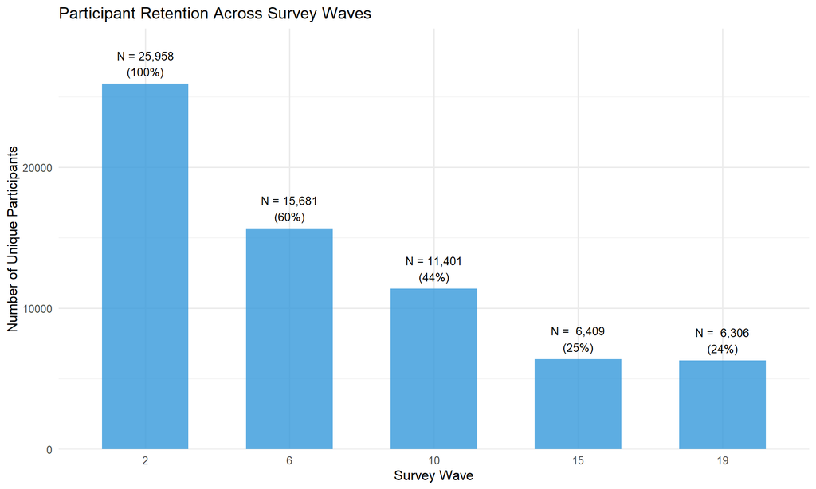

Participant Retention Across Waves

```r
# 流失率可视化
retention <- df_model %>%
  group_by(Time) %>%
  summarise(n = n_distinct(token), .groups = "drop") %>%
  mutate(retention_pct = n / max(n) * 100,
         label = sprintf("N = %s\n(%.0f%%)", format(n, big.mark = ","), retention_pct))

ggplot(retention, aes(x = factor(Time), y = n)) +
  geom_col(fill = "#3498DB", alpha = 0.8, width = 0.6) +
  geom_text(aes(label = label), vjust = -0.3, size = 3.5) +
  scale_y_continuous(expand = expansion(mult = c(0, 0.15))) +
  labs(title = "Participant Retention Across Survey Waves",
       x = "Survey Wave", y = "Number of Unique Participants") +
  theme_minimal(base_size = 12)
```

```r
baseline_all <- df_model %>%
  filter(Time == 2) %>%
  dplyr::select(token, NS_1, AD_5, hc_01_ref, hc04)

last_wave_participants <- df_model %>% filter(Time == 19) %>% distinct(token)

baseline_all %>%
  mutate(retained = ifelse(token %in% last_wave_participants$token,
                           "Retained to Wave 19", "Dropped out")) %>%
  dplyr::select(-token) %>%
  tbl_summary(
    by = retained,
    label = list(NS_1 ~ "Baseline BMI", AD_5 ~ "Baseline Depression",
                 hc_01_ref ~ "Age", hc04 ~ "Sex"),
    statistic = list(all_continuous() ~ "{mean} ({sd})"), missing = "no"
  ) %>%
  add_p() %>% bold_p() %>% bold_labels()
```

| **Characteristic** | **Dropped out** N = 22,698<sup>1</sup> | **Retained to Wave 19** N = 3,266<sup>1</sup> | **p-value**<sup>2</sup> |
| --- | --- | --- | --- |
| Baseline BMI | 25.9 (5.0) | 26.0 (4.7) | 0.003 |
| Baseline Depression |  |  | <0.001 |
| 0 | 6,164 (56%) | 1,270 (66%) |  |
| 1 | 2,821 (26%) | 443 (23%) |  |
| 2 | 1,073 (9.8%) | 121 (6.3%) |  |
| 3 | 565 (5.2%) | 55 (2.8%) |  |
| 4 | 302 (2.8%) | 43 (2.2%) |  |
| Age | 49 (14) | 56 (13) | <0.001 |
| Sex |  |  | <0.001 |
| 1 | 7,107 (31%) | 1,209 (37%) |  |
| 2 | 15,591 (69%) | 2,057 (63%) |  |

<sup>1</sup> Mean (SD); n (%)  
<sup>2</sup> Wilcoxon rank sum test; Pearson’s Chi-squared test

## 3.5 缺失数据

```r
df_model %>%
  group_by(Wave = Time) %>%
  summarise(
    `BMI missing (%)` = round(mean(is.na(NS_1)) * 100, 1),
    `Depression missing (%)` = round(mean(is.na(AD_5)) * 100, 1),
    `Age missing (%)` = round(mean(is.na(hc_01_ref)) * 100, 1),
    `Sex missing (%)` = round(mean(is.na(hc04)) * 100, 1),
    `Education missing (%)` = round(mean(is.na(et_1_ref)) * 100, 1),
    .groups = "drop"
  ) %>%
  knitr::kable(caption = "Percentage of Missing Values by Wave")
```

Percentage of Missing Values by Wave

| Wave | BMI missing (%) | Depression missing (%) | Age missing (%) | Sex missing (%) | Education missing (%) |
| --- | --- | --- | --- | --- | --- |
| 2 | 1.1 | 50.5 | 0.0 | 0.0 | 1.8 |
| 6 | 1.4 | 1.3 | 0.0 | 0.0 | 0.9 |
| 10 | 1.4 | 0.8 | 0.0 | 0.0 | 0.7 |
| 15 | 0.9 | 2.0 | 0.0 | 0.1 | 0.0 |
| 19 | 1.0 | 1.8 | 0.1 | 0.1 | 0.1 |

```r
# 完整案例数
df_model %>%
  filter(!is.na(NS_1) & !is.na(AD_5) & !is.na(hc04) & !is.na(et_1_ref) & !is.na(hc_01_ref)) %>%
  group_by(Time) %>%
  summarise(n_complete = n(), .groups = "drop") %>%
  knitr::kable(caption = "Complete Cases per Wave (all model variables present)")
```

Complete Cases per Wave (all model variables present)

| Time | n_complete |
| --- | --- |
| 2 | 12565 |
| 6 | 15142 |
| 10 | 11078 |
| 15 | 6220 |
| 19 | 6125 |

## 3.6 变量分布

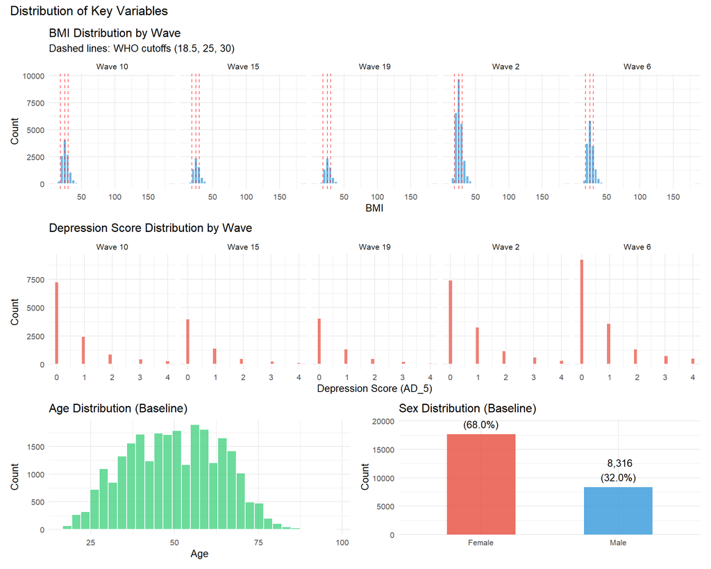

Distribution of Key Variables

```r
p_bmi_dist <- df_model %>%
  filter(!is.na(NS_1)) %>%
  ggplot(aes(x = NS_1)) +
  geom_histogram(bins = 40, fill = "#3498DB", alpha = 0.7, color = "white") +
  geom_vline(xintercept = c(18.5, 25, 30), linetype = "dashed", color = "red", alpha = 0.6) +
  facet_wrap(~ paste("Wave", Time), nrow = 1) +
  labs(title = "BMI Distribution by Wave",
       subtitle = "Dashed lines: WHO cutoffs (18.5, 25, 30)",
       x = "BMI", y = "Count") +
  theme_minimal(base_size = 10)

p_dep_dist <- df_model %>%
  filter(!is.na(AD_5)) %>%
  ggplot(aes(x = AD_5)) +
  geom_histogram(bins = 30, fill = "#E74C3C", alpha = 0.7, color = "white") +
  facet_wrap(~ paste("Wave", Time), nrow = 1) +
  labs(title = "Depression Score Distribution by Wave",
       x = "Depression Score (AD_5)", y = "Count") +
  theme_minimal(base_size = 10)

p_age_dist <- df_model %>%
  filter(Time == 2 & !is.na(hc_01_ref)) %>%
  ggplot(aes(x = hc_01_ref)) +
  geom_histogram(bins = 30, fill = "#2ECC71", alpha = 0.7, color = "white") +
  labs(title = "Age Distribution (Baseline)", x = "Age", y = "Count") +
  theme_minimal(base_size = 10)

p_sex_dist <- df_model %>%
  filter(Time == 2 & !is.na(hc04)) %>%
  count(hc04) %>%
  mutate(sex_label = ifelse(hc04 == 1, "Male", "Female"),
         pct = round(n / sum(n) * 100, 1),
         label = sprintf("%s\n(%.1f%%)", format(n, big.mark = ","), pct)) %>%
  ggplot(aes(x = sex_label, y = n, fill = sex_label)) +
  geom_col(alpha = 0.8, width = 0.5) +
  geom_text(aes(label = label), vjust = -0.3, size = 3.5) +
  scale_fill_manual(values = c("Male" = "#3498DB", "Female" = "#E74C3C")) +
  scale_y_continuous(expand = expansion(mult = c(0, 0.15))) +
  labs(title = "Sex Distribution (Baseline)", x = "", y = "Count") +
  theme_minimal(base_size = 10) + theme(legend.position = "none")

(p_bmi_dist / p_dep_dist) / (p_age_dist + p_sex_dist) +
  plot_annotation(title = "Distribution of Key Variables")
```

## 3.7 BMI 与抑郁的相关性

```r
cor_by_wave <- df_model %>%
  filter(!is.na(NS_1) & !is.na(AD_5)) %>%
  group_by(Time) %>%
  summarise(r = cor(NS_1, AD_5), n = n(), .groups = "drop") %>%
  mutate(t_stat = r * sqrt((n - 2) / (1 - r^2)),
         p_value = 2 * pt(abs(t_stat), df = n - 2, lower.tail = FALSE),
         sig = ifelse(p_value < 0.001, "***", ifelse(p_value < 0.01, "**",
               ifelse(p_value < 0.05, "*", "ns"))))

cor_by_wave %>%
  dplyr::select(Wave = Time, `Pearson r` = r, N = n, `p-value` = p_value, Sig = sig) %>%
  knitr::kable(digits = 4, caption = "BMI-Depression Correlation by Wave")
```

BMI-Depression Correlation by Wave

| Wave | Pearson r | N | p-value | Sig |
| --- | --- | --- | --- | --- |
| 2 | 0.0765 | 12709 | 0 | *** |
| 6 | 0.0863 | 15275 | 0 | *** |
| 10 | 0.0663 | 11149 | 0 | *** |
| 15 | 0.1067 | 6224 | 0 | *** |
| 19 | 0.1096 | 6131 | 0 | *** |

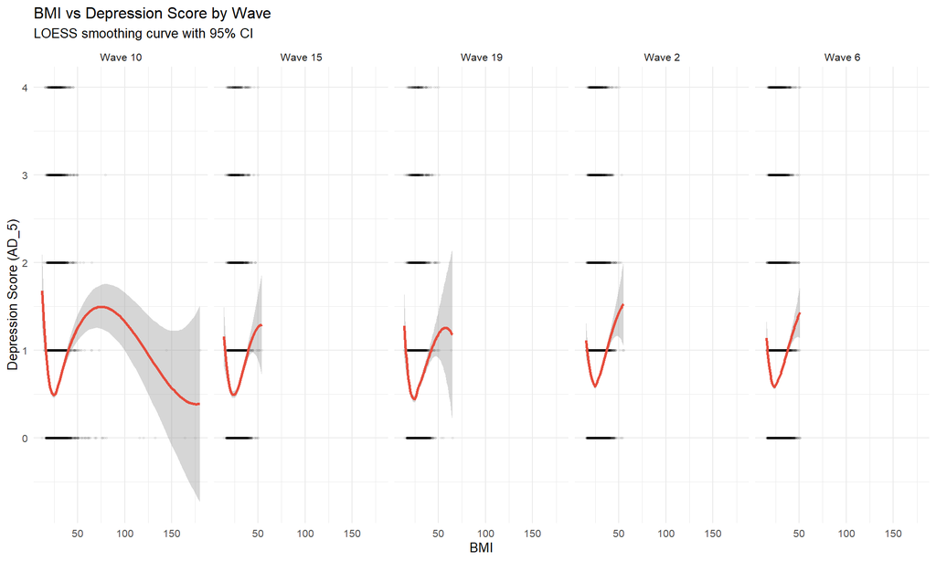

BMI-Depression Correlation by Wave

```r
df_model %>%
  filter(!is.na(NS_1) & !is.na(AD_5)) %>%
  ggplot(aes(x = NS_1, y = AD_5)) +
  geom_point(alpha = 0.05, size = 0.5) +
  geom_smooth(method = "loess", color = "#E74C3C", se = TRUE, linewidth = 1) +
  facet_wrap(~ paste("Wave", Time), nrow = 1) +
  labs(title = "BMI vs Depression Score by Wave",
       subtitle = "LOESS smoothing curve with 95% CI",
       x = "BMI", y = "Depression Score (AD_5)") +
  theme_minimal(base_size = 10)
```

## 3.8 纵向变化趋势

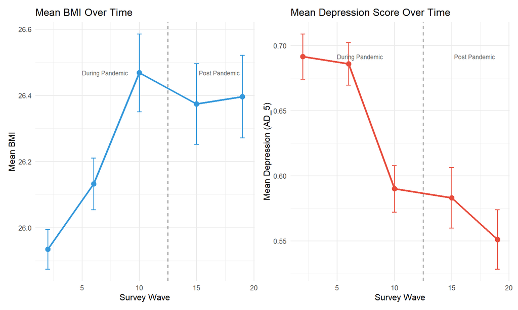

Longitudinal Trends in BMI and Depression

```r
trends <- df_model %>%
  group_by(Time) %>%
  summarise(BMI = mean(NS_1, na.rm = TRUE),
            BMI_se = sd(NS_1, na.rm = TRUE) / sqrt(sum(!is.na(NS_1))),
            Depression = mean(AD_5, na.rm = TRUE),
            Depression_se = sd(AD_5, na.rm = TRUE) / sqrt(sum(!is.na(AD_5))),
            .groups = "drop")

p_trend_bmi <- ggplot(trends, aes(x = Time, y = BMI)) +
  geom_line(color = "#3498DB", linewidth = 1.2) + geom_point(color = "#3498DB", size = 3) +
  geom_errorbar(aes(ymin = BMI - 1.96*BMI_se, ymax = BMI + 1.96*BMI_se), width = 0.4, color = "#3498DB") +
  geom_vline(xintercept = 12.5, linetype = "dashed", alpha = 0.5) +
  annotate("text", x = 7, y = max(trends$BMI), label = "During Pandemic", size = 3, alpha = 0.6) +
  annotate("text", x = 17, y = max(trends$BMI), label = "Post Pandemic", size = 3, alpha = 0.6) +
  labs(title = "Mean BMI Over Time", x = "Survey Wave", y = "Mean BMI") +
  theme_minimal(base_size = 12)

p_trend_dep <- ggplot(trends, aes(x = Time, y = Depression)) +
  geom_line(color = "#E74C3C", linewidth = 1.2) + geom_point(color = "#E74C3C", size = 3) +
  geom_errorbar(aes(ymin = Depression - 1.96*Depression_se, ymax = Depression + 1.96*Depression_se),
                width = 0.4, color = "#E74C3C") +
  geom_vline(xintercept = 12.5, linetype = "dashed", alpha = 0.5) +
  annotate("text", x = 7, y = max(trends$Depression), label = "During Pandemic", size = 3, alpha = 0.6) +
  annotate("text", x = 17, y = max(trends$Depression), label = "Post Pandemic", size = 3, alpha = 0.6) +
  labs(title = "Mean Depression Score Over Time", x = "Survey Wave", y = "Mean Depression (AD_5)") +
  theme_minimal(base_size = 12)

p_trend_bmi + p_trend_dep
```

## 3.9 各 BMI 类别的抑郁得分（基线）

```r
df_baseline_bmi <- df_model %>%
  filter(Time == 2 & !is.na(BMI_category) & !is.na(AD_5))

df_baseline_bmi %>%
  dplyr::select(`BMI Category` = BMI_category, `Depression` = AD_5) %>%
  tbl_summary(by = `BMI Category`,
              statistic = list(all_continuous() ~ "{mean} ({sd})"),
              label = list(Depression ~ "Depression Score (AD_5)")) %>%
  add_p() %>% bold_p() %>% bold_labels()
```

| **Characteristic** | **Normal** N = 6,220<sup>1</sup> | **Underweight** N = 270<sup>1</sup> | **Overweight** N = 4,040<sup>1</sup> | **Obese** N = 2,179<sup>1</sup> | **p-value**<sup>2</sup> |
| --- | --- | --- | --- | --- | --- |
| Depression Score (AD_5) |  |  |  |  | <0.001 |
| 0 | 3,692 (59%) | 133 (49%) | 2,443 (60%) | 1,081 (50%) |  |
| 1 | 1,590 (26%) | 73 (27%) | 965 (24%) | 601 (28%) |  |
| 2 | 538 (8.6%) | 37 (14%) | 346 (8.6%) | 258 (12%) |  |
| 3 | 246 (4.0%) | 19 (7.0%) | 194 (4.8%) | 150 (6.9%) |  |
| 4 | 154 (2.5%) | 8 (3.0%) | 92 (2.3%) | 89 (4.1%) |  |

<sup>1</sup> n (%)  
<sup>2</sup> Pearson’s Chi-squared test

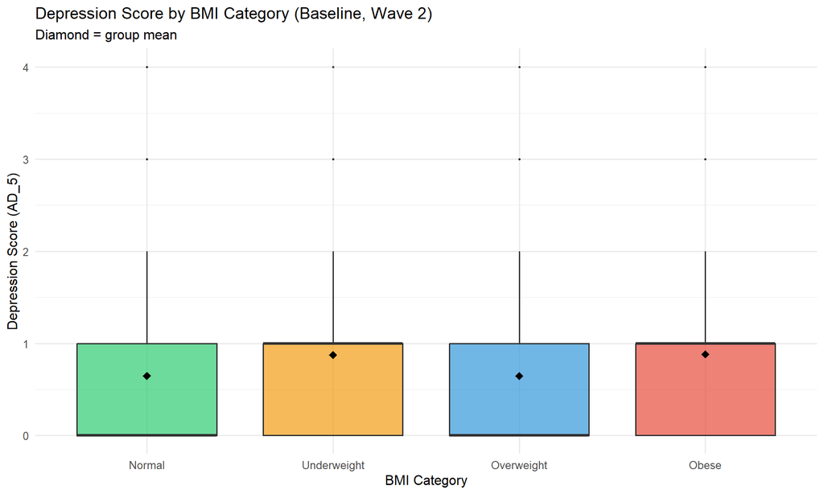

Depression Score by BMI Category at Baseline

```r
df_baseline_bmi %>%
  ggplot(aes(x = BMI_category, y = AD_5, fill = BMI_category)) +
  geom_boxplot(alpha = 0.7, outlier.alpha = 0.2, outlier.size = 0.5) +
  stat_summary(fun = mean, geom = "point", shape = 18, size = 3, color = "black") +
  scale_fill_manual(values = c("Normal"="#2ECC71","Underweight"="#F39C12",
                                "Overweight"="#3498DB","Obese"="#E74C3C")) +
  labs(title = "Depression Score by BMI Category (Baseline, Wave 2)",
       subtitle = "Diamond = group mean", x = "BMI Category", y = "Depression Score (AD_5)") +
  theme_minimal(base_size = 12) + theme(legend.position = "none")
```

# 4 第一部分：BMI 与抑郁的双向关系分析

> **注意**：以下纵向分析均使用 `df_longitudinal`（≥2 波次样本）。

## 4.1 基础双向线性混合模型

### 4.1.1 方向 A: BMI → 抑郁

```r
m_bmi_to_dep <- lmer(
  AD_5 ~ NS_1 * Time + Age_centered + hc04 + et_1_ref + (1 | token),
  data = df_longitudinal, REML = FALSE,
  control = lmerControl(optimizer = "bobyqa", optCtrl = list(maxfun = 2e5))
)

summary(m_bmi_to_dep)
```

```
## Linear mixed model fit by maximum likelihood . t-tests use Satterthwaite's
##   method [lmerModLmerTest]
## Formula: AD_5 ~ NS_1 * Time + Age_centered + hc04 + et_1_ref + (1 | token)
##    Data: df_longitudinal
## Control: lmerControl(optimizer = "bobyqa", optCtrl = list(maxfun = 200000))
##
##       AIC       BIC    logLik -2*log(L)  df.resid
##   85049.7   85126.1  -42515.9   85031.7     35866
##
## Scaled residuals:
##     Min      1Q  Median      3Q     Max
## -3.9991 -0.3469 -0.1458  0.1622  5.4330
##
## Random effects:
##  Groups   Name        Variance Std.Dev.
##  token    (Intercept) 0.5148   0.7175
##  Residual             0.3560   0.5966
## Number of obs: 35875, groups:  token, 12769
##
## Fixed effects:
##                    Estimate     Std. Error             df t value
## (Intercept)      0.32212757     0.04991867 35287.39434597   6.453
## NS_1             0.01282141     0.00173964 35823.27993186   7.370
## Time            -0.00342634     0.00356831 28505.52988890  -0.960
## Age_centered    -0.01402761     0.00053714 12854.37921817 -26.115
## hc042            0.14526324     0.01506173 13018.44712387   9.645
## et_1_ref2       -0.12916189     0.01650756 13526.59053073  -7.824
## NS_1:Time        0.00001821     0.00013376 28536.26012660   0.136
##                          Pr(>|t|)
## (Intercept)   0.00000000011104138 ***
## NS_1          0.00000000000017412 ***
## Time                        0.337
## Age_centered < 0.0000000000000002 ***
## hc042        < 0.0000000000000002 ***
## et_1_ref2     0.00000000000000548 ***
## NS_1:Time                   0.892
## ---
## Signif. codes:  0 '***' 0.001 '**' 0.01 '*' 0.05 '.' 0.1 ' ' 1
##
## Correlation of Fixed Effects:
##             (Intr) NS_1   Time   Ag_cnt hc042  et_1_2
## NS_1        -0.932
## Time        -0.703  0.745
## Age_centerd -0.025 -0.054 -0.035
## hc042       -0.227  0.047  0.006  0.196
## et_1_ref2   -0.295  0.060  0.007  0.102 -0.044
## NS_1:Time    0.696 -0.762 -0.983  0.025 -0.004 -0.009
```

```r
cat("\n效应量（R²）：\n")
```

```
##
## 效应量（R²）：
```

```r
print(r2_nakagawa(m_bmi_to_dep))
```

```
## # R2 for Mixed Models
##
##   Conditional R2: 0.613
##      Marginal R2: 0.054
```

### 4.1.2 方向 B: 抑郁 → BMI

```r
m_dep_to_bmi <- lmer(
  NS_1 ~ AD_5 * Time + Age_centered + hc04 + et_1_ref + (1 | token),
  data = df_longitudinal, REML = FALSE,
  control = lmerControl(optimizer = "bobyqa", optCtrl = list(maxfun = 2e5))
)

summary(m_dep_to_bmi)
```

```
## Linear mixed model fit by maximum likelihood . t-tests use Satterthwaite's
##   method [lmerModLmerTest]
## Formula: NS_1 ~ AD_5 * Time + Age_centered + hc04 + et_1_ref + (1 | token)
##    Data: df_longitudinal
## Control: lmerControl(optimizer = "bobyqa", optCtrl = list(maxfun = 200000))
##
##       AIC       BIC    logLik -2*log(L)  df.resid
##  191784.6  191861.0  -95883.3  191766.6     35866
##
## Scaled residuals:
##     Min      1Q  Median      3Q     Max
## -22.241  -0.240  -0.040   0.206  51.289
##
## Random effects:
##  Groups   Name        Variance Std.Dev.
##  token    (Intercept) 21.700   4.658
##  Residual              4.969   2.229
## Number of obs: 35875, groups:  token, 12769
##
## Fixed effects:
##                  Estimate   Std. Error           df t value
## (Intercept)     27.411893     0.105185 16792.754422 260.607
## AD_5             0.062722     0.034167 28363.578299   1.836
## Time             0.012560     0.002966 25145.601071   4.234
## Age_centered     0.028159     0.003224 13249.275540   8.733
## hc042           -0.938825     0.089214 14011.156318 -10.523
## et_1_ref2       -1.122284     0.096416 15198.918088 -11.640
## AD_5:Time        0.009858     0.002793 25503.207544   3.529
##                          Pr(>|t|)
## (Intercept)  < 0.0000000000000002 ***
## AD_5                     0.066406 .
## Time                     0.000023 ***
## Age_centered < 0.0000000000000002 ***
## hc042        < 0.0000000000000002 ***
## et_1_ref2    < 0.0000000000000002 ***
## AD_5:Time                0.000418 ***
## ---
## Signif. codes:  0 '***' 0.001 '**' 0.01 '*' 0.05 '.' 0.1 ' ' 1
##
## Correlation of Fixed Effects:
##             (Intr) AD_5   Time   Ag_cnt hc042  et_1_2
## AD_5        -0.198
## Time        -0.267  0.405
## Age_centerd -0.231  0.065 -0.027
## hc042       -0.508 -0.025  0.006  0.196
## et_1_ref2   -0.671  0.021 -0.007  0.107 -0.047
## AD_5:Time    0.139 -0.757 -0.517 -0.005  0.004 -0.001
```

```r
cat("\n效应量（R²）：\n")
```

```
##
## 效应量（R²）：
```

```r
print(r2_nakagawa(m_dep_to_bmi))
```

```
## # R2 for Mixed Models
##
##   Conditional R2: 0.819
##      Marginal R2: 0.028
```

### 4.1.3 对比表格

```r
tab_model(
  m_bmi_to_dep, m_dep_to_bmi,
  show.ci = 0.95, show.se = TRUE,
  dv.labels = c("BMI → Depression", "Depression → BMI"),
  pred.labels = c("NS_1" = "BMI", "AD_5" = "Depression", "Time" = "Time",
                  "NS_1:Time" = "BMI × Time", "AD_5:Time" = "Depression × Time")
)
```

|  | BMI → Depression |  |  |  | Depression → BMI |  |  |  |
| --- | --- | --- | --- | --- | --- | --- | --- | --- |
| Predictors | Estimates | std. Error | CI | p | Estimates | std. Error | CI | p |
| (Intercept) | 0.32 | 0.05 | 0.22 – 0.42 | **<0.001** | 27.41 | 0.11 | 27.21 – 27.62 | **<0.001** |
| BMI | 0.01 | 0.00 | 0.01 – 0.02 | **<0.001** |  |  |  |  |
| Time | -0.00 | 0.00 | -0.01 – 0.00 | 0.337 | 0.01 | 0.00 | 0.01 – 0.02 | **<0.001** |
| Age_centered | -0.01 | 0.00 | -0.02 – -0.01 | **<0.001** | 0.03 | 0.00 | 0.02 – 0.03 | **<0.001** |
| hc042 | 0.15 | 0.02 | 0.12 – 0.17 | **<0.001** | -0.94 | 0.09 | -1.11 – -0.76 | **<0.001** |
| et_1_ref2 | -0.13 | 0.02 | -0.16 – -0.10 | **<0.001** | -1.12 | 0.10 | -1.31 – -0.93 | **<0.001** |
| BMI × Time | 0.00 | 0.00 | -0.00 – 0.00 | 0.892 |  |  |  |  |
| Depression |  |  |  |  | 0.06 | 0.03 | -0.00 – 0.13 | 0.066 |
| Depression × Time |  |  |  |  | 0.01 | 0.00 | 0.00 – 0.02 | **<0.001** |
| Random Effects |  |  |  |  |  |  |  |  |
| σ<sup>2</sup> | 0.36 |  |  |  | 4.97 |  |  |  |
| τ<sub>00</sub> | 0.51 <sub>token</sub> |  |  |  | 21.70 <sub>token</sub> |  |  |  |
| ICC | 0.59 |  |  |  | 0.81 |  |  |  |
| N | 12769 <sub>token</sub> |  |  |  | 12769 <sub>token</sub> |  |  |  |
| Observations | 35875 |  |  |  | 35875 |  |  |  |
| Marginal R<sup>2</sup> / Conditional R<sup>2</sup> | 0.054 / 0.613 |  |  |  | 0.028 / 0.819 |  |  |  |

## 4.2 滞后效应分析

```r
df_lagged <- df_longitudinal %>%
  arrange(token, Time) %>%
  group_by(token) %>%
  mutate(BMI_lag1 = lag(NS_1, 1), Depression_lag1 = lag(AD_5, 1)) %>%
  ungroup() %>%
  filter(!is.na(BMI_lag1) & !is.na(Depression_lag1))

cat(sprintf("滞后分析样本: %d 观测, %d 个体\n", nrow(df_lagged), n_distinct(df_lagged$token)))
```

```
## 滞后分析样本: 23300 观测, 12808 个体
```

```r
m_lagged_bmi_dep <- lmer(
  AD_5 ~ BMI_lag1 + NS_1 + Depression_lag1 + Time +
    Age_centered + hc04 + et_1_ref + (1 | token),
  data = df_lagged, REML = FALSE,
  control = lmerControl(optimizer = "bobyqa", check.conv.singular = "ignore")
)

m_lagged_dep_bmi <- lmer(
  NS_1 ~ Depression_lag1 + AD_5 + BMI_lag1 + Time +
    Age_centered + hc04 + et_1_ref + (1 | token),
  data = df_lagged, REML = FALSE,
  control = lmerControl(optimizer = "bobyqa", check.conv.singular = "ignore")
)

cat("\n关键发现（滞后效应）：\n")
```

```
##
## 关键发现（滞后效应）：
```

```r
cat(sprintf("  上期 BMI → 当期抑郁: β = %.3f, p = %.4f\n",
            fixef(m_lagged_bmi_dep)["BMI_lag1"],
            summary(m_lagged_bmi_dep)$coefficients["BMI_lag1", "Pr(>|t|)"]))
```

```
##   上期 BMI → 当期抑郁: β = 0.002, p = 0.2168
```

```r
cat(sprintf("  上期抑郁 → 当期 BMI: β = %.3f, p = %.4f\n",
            fixef(m_lagged_dep_bmi)["Depression_lag1"],
            summary(m_lagged_dep_bmi)$coefficients["Depression_lag1", "Pr(>|t|)"]))
```

```
##   上期抑郁 → 当期 BMI: β = 0.048, p = 0.0931
```

```r
tab_model(
  m_lagged_bmi_dep, m_lagged_dep_bmi,
  show.ci = 0.95, show.se = TRUE,
  dv.labels = c("Lagged BMI → Depression", "Lagged Depression → BMI")
)
```

|  | Lagged BMI → Depression |  |  |  | Lagged Depression → BMI |  |  |  |
| --- | --- | --- | --- | --- | --- | --- | --- | --- |
| Predictors | Estimates | std. Error | CI | p | Estimates | std. Error | CI | p |
| (Intercept) | 0.09 | 0.03 | 0.03 – 0.15 | **0.005** | 5.17 | 0.13 | 4.90 – 5.43 | **<0.001** |
| BMI_lag1 | 0.00 | 0.00 | -0.00 – 0.00 | 0.217 | 0.82 | 0.00 | 0.81 – 0.82 | **<0.001** |
| BMI - continuous | 0.01 | 0.00 | 0.00 – 0.01 | **<0.001** |  |  |  |  |
| Depression_lag1 | 0.60 | 0.01 | 0.58 – 0.61 | **<0.001** | 0.05 | 0.03 | -0.01 – 0.10 | 0.093 |
| Time | -0.00 | 0.00 | -0.01 – -0.00 | **<0.001** | -0.01 | 0.00 | -0.02 – -0.00 | **0.024** |
| Age_centered | -0.00 | 0.00 | -0.01 – -0.00 | **<0.001** | -0.00 | 0.00 | -0.00 – 0.00 | 0.642 |
| hc04: hc042 | 0.04 | 0.01 | 0.02 – 0.06 | **<0.001** | -0.16 | 0.05 | -0.24 – -0.07 | **0.001** |
| et_1_ref: et_1_ref2 | -0.05 | 0.01 | -0.07 – -0.03 | **<0.001** | -0.16 | 0.05 | -0.26 – -0.06 | **0.002** |
| AD_5 |  |  |  |  | 0.11 | 0.03 | 0.06 – 0.17 | **<0.001** |
| Random Effects |  |  |  |  |  |  |  |  |
| σ<sup>2</sup> | 0.54 |  |  |  | 10.34 |  |  |  |
| τ<sub>00</sub> | 0.00 <sub>token</sub> |  |  |  | 0.00 <sub>token</sub> |  |  |  |
| N | 12713 <sub>token</sub> |  |  |  | 12713 <sub>token</sub> |  |  |  |
| Observations | 22959 |  |  |  | 22959 |  |  |  |
| Marginal R<sup>2</sup> / Conditional R<sup>2</sup> | 0.397 / NA |  |  |  | 0.645 / NA |  |  |  |

## 4.3 疫情阶段调节效应

```r
m_phase_mod_dep <- lmer(
  AD_5 ~ NS_1 * Phase + Age_centered + hc04 + et_1_ref + (1 | token),
  data = df_longitudinal, REML = FALSE
)

m_phase_mod_bmi <- lmer(
  NS_1 ~ AD_5 * Phase + Age_centered + hc04 + et_1_ref + (1 | token),
  data = df_longitudinal, REML = FALSE
)

tab_model(
  m_phase_mod_dep, m_phase_mod_bmi,
  show.ci = 0.95,
  dv.labels = c("BMI → Depression (Phase Mod.)", "Depression → BMI (Phase Mod.)")
)
```

|  | BMI → Depression (Phase Mod.) |  |  | Depression → BMI (Phase Mod.) |  |  |
| --- | --- | --- | --- | --- | --- | --- |
| Predictors | Estimates | CI | p | Estimates | CI | p |
| (Intercept) | 0.31 | 0.24 – 0.38 | **<0.001** | 27.52 | 27.32 – 27.72 | **<0.001** |
| BMI - continuous | 0.01 | 0.01 – 0.01 | **<0.001** |  |  |  |
| Phase: Post-Pandemic | -0.07 | -0.15 – 0.01 | 0.096 | 0.04 | -0.03 – 0.11 | 0.305 |
| Age_centered | -0.01 | -0.02 – -0.01 | **<0.001** | 0.03 | 0.02 – 0.04 | **<0.001** |
| hc04: hc042 | 0.15 | 0.12 – 0.18 | **<0.001** | -0.94 | -1.12 – -0.77 | **<0.001** |
| et_1_ref: et_1_ref2 | -0.13 | -0.16 – -0.10 | **<0.001** | -1.12 | -1.31 – -0.93 | **<0.001** |
| NS_1:PhasePost-Pandemic | 0.00 | -0.00 – 0.01 | 0.182 |  |  |  |
| AD_5 |  |  |  | 0.12 | 0.08 – 0.17 | **<0.001** |
| AD_5:PhasePost-Pandemic |  |  |  | 0.09 | 0.03 – 0.16 | **0.005** |
| Random Effects |  |  |  |  |  |  |
| σ<sup>2</sup> | 0.36 |  |  | 4.98 |  |  |
| τ<sub>00</sub> | 0.51 <sub>token</sub> |  |  | 21.71 <sub>token</sub> |  |  |
| ICC | 0.59 |  |  | 0.81 |  |  |
| N | 12769 <sub>token</sub> |  |  | 12769 <sub>token</sub> |  |  |
| Observations | 35875 |  |  | 35875 |  |  |
| Marginal R<sup>2</sup> / Conditional R<sup>2</sup> | 0.054 / 0.613 |  |  | 0.027 / 0.819 |  |  |

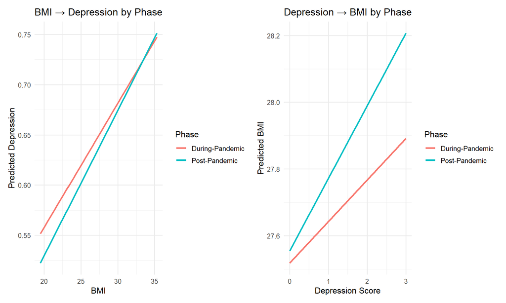

BMI-Depression Association by Pandemic Phase

```r
# 手动预测，避免 OOM
bmi_range <- seq(quantile(df_longitudinal$NS_1, 0.05, na.rm = TRUE),
                 quantile(df_longitudinal$NS_1, 0.95, na.rm = TRUE), length.out = 50)

newdata_dep <- expand.grid(NS_1 = bmi_range, Phase = levels(df_longitudinal$Phase)) %>%
  mutate(Age_centered = 0,
         hc04 = factor(levels(df_longitudinal$hc04)[1], levels = levels(df_longitudinal$hc04)),
         et_1_ref = factor(levels(df_longitudinal$et_1_ref)[1], levels = levels(df_longitudinal$et_1_ref)))
newdata_dep$pred <- predict(m_phase_mod_dep, newdata = newdata_dep, re.form = NA)

p_phase_dep <- ggplot(newdata_dep, aes(x = NS_1, y = pred, color = Phase)) +
  geom_line(linewidth = 1.2) +
  labs(title = "BMI → Depression by Phase", x = "BMI", y = "Predicted Depression") +
  theme_minimal(base_size = 12)

dep_range <- seq(quantile(df_longitudinal$AD_5, 0.05, na.rm = TRUE),
                 quantile(df_longitudinal$AD_5, 0.95, na.rm = TRUE), length.out = 50)

newdata_bmi <- expand.grid(AD_5 = dep_range, Phase = levels(df_longitudinal$Phase)) %>%
  mutate(Age_centered = 0,
         hc04 = factor(levels(df_longitudinal$hc04)[1], levels = levels(df_longitudinal$hc04)),
         et_1_ref = factor(levels(df_longitudinal$et_1_ref)[1], levels = levels(df_longitudinal$et_1_ref)))
newdata_bmi$pred <- predict(m_phase_mod_bmi, newdata = newdata_bmi, re.form = NA)

p_phase_bmi <- ggplot(newdata_bmi, aes(x = AD_5, y = pred, color = Phase)) +
  geom_line(linewidth = 1.2) +
  labs(title = "Depression → BMI by Phase", x = "Depression Score", y = "Predicted BMI") +
  theme_minimal(base_size = 12)

p_phase_dep + p_phase_bmi
```

# 5 第二部分：潜类别轨迹分析

## 5.1 抑郁症状的潜类别轨迹

```r
# [修复] 使用纵向样本，确保每人 ≥2 观测
df_lcmm <- df_longitudinal %>%
  filter(!is.na(AD_5) & !is.na(NS_1) & !is.na(Time) &
         !is.na(Age_centered) & !is.na(hc04) & !is.na(et_1_ref)) %>%
  as.data.frame()

cat(sprintf("LCGA 样本: %d 观测, %d 个体\n", nrow(df_lcmm), n_distinct(df_lcmm$token_num)))
```

```
## LCGA 样本: 35875 观测, 12769 个体
```

```r
# 1 类基准模型
m_dep_lcga_1 <- hlme(
  AD_5 ~ Time + Age_centered + hc04 + et_1_ref,
  random = ~ 1, subject = 'token_num', ng = 1,
  data = df_lcmm, verbose = FALSE
)

# [修复] 使用 gridsearch 代替手动循环
cat("\n拟合 2 类抑郁轨迹模型...\n")
```

```
##
## 拟合 2 类抑郁轨迹模型...
```

```r
m_dep_lcga_2 <- tryCatch({
  gridsearch(
    rep = 50, maxiter = 30, minit = m_dep_lcga_1,
    hlme(AD_5 ~ Time + Age_centered + hc04 + et_1_ref,
         mixture = ~ Time, random = ~ 1, subject = 'token_num', ng = 2,
         data = df_lcmm, verbose = FALSE, maxiter = 1000)
  )
}, error = function(e) { cat(sprintf("  ✗ 失败: %s\n", e$message)); NULL })

cat("拟合 3 类抑郁轨迹模型...\n")
```

```
## 拟合 3 类抑郁轨迹模型...
```

```r
m_dep_lcga_3 <- tryCatch({
  gridsearch(
    rep = 50, maxiter = 30, minit = m_dep_lcga_1,
    hlme(AD_5 ~ Time + Age_centered + hc04 + et_1_ref,
         mixture = ~ Time, random = ~ 1, subject = 'token_num', ng = 3,
         data = df_lcmm, verbose = FALSE, maxiter = 1000)
  )
}, error = function(e) { cat(sprintf("  ✗ 失败: %s\n", e$message)); NULL })

cat("拟合 4 类抑郁轨迹模型...\n")
```

```
## 拟合 4 类抑郁轨迹模型...
```

```r
m_dep_lcga_4 <- tryCatch({
  gridsearch(
    rep = 50, maxiter = 30, minit = m_dep_lcga_1,
    hlme(AD_5 ~ Time + Age_centered + hc04 + et_1_ref,
         mixture = ~ Time, random = ~ 1, subject = 'token_num', ng = 4,
         data = df_lcmm, verbose = FALSE, maxiter = 1000)
  )
}, error = function(e) { cat(sprintf("  ✗ 失败: %s\n", e$message)); NULL })
```

```r
dep_models <- list(m_dep_lcga_1, m_dep_lcga_2, m_dep_lcga_3, m_dep_lcga_4)
dep_models <- dep_models[!sapply(dep_models, is.null)]

best_dep_model <- dep_models[[1]]
best_dep_idx <- 1

if (length(dep_models) > 1) {
  # [修复] 检查类别占比时使用 nrow(model$pprob) 而非 nrow(data)
  valid_dep_models <- list(dep_models[[1]])  # 1-class always valid
  for (i in 2:length(dep_models)) {
    m <- dep_models[[i]]
    if (!is.null(m) && !is.null(m$pprob)) {
      class_props <- table(m$pprob$class) / nrow(m$pprob)
      if (min(class_props) > 0.05) {
        valid_dep_models <- c(valid_dep_models, list(m))
        cat(sprintf("✓ %d 类模型有效（最小类: %.1f%%）\n", i, min(class_props) * 100))
      } else {
        cat(sprintf("✗ %d 类模型有空类（最小: %.1f%%）\n", i, min(class_props) * 100))
      }
    }
  }

  if (length(valid_dep_models) > 1) {
    dep_compare <- do.call(summarytable, valid_dep_models)
    cat("\n抑郁轨迹模型比较：\n")
    print(dep_compare)

    best_dep_idx <- which.min(sapply(valid_dep_models, function(m) m$BIC))
    best_dep_model <- valid_dep_models[[best_dep_idx]]
    cat(sprintf("\n✓ 最优: %d 类 (BIC = %.1f)\n",
                best_dep_model$ng, best_dep_model$BIC))
  } else {
    cat("\n仅 1 类模型通过验证\n")
  }
} else {
  cat("仅 1 类模型成功拟合\n")
}
```

```
## ✓ 2 类模型有效（最小类: 12.1%）
## ✓ 3 类模型有效（最小类: 7.1%）
## ✓ 4 类模型有效（最小类: 13.6%）
##                  G    loglik npm      BIC    %class1  %class2   %class3 %class4
## 12769            1 -42581.83   7 85229.84 100.000000
## 1                2 -39968.29  10 80031.14  87.939541 12.06046
## c(1, 0, 0, 0, 0) 3 -39054.10  13 78231.11   7.768815 85.08889  7.142298
## c(0, 0, 0, 0, 0) 4 -39968.29  16 80087.87  86.365416  0.00000 13.634584       0
##
## 抑郁轨迹模型比较：
##                  G    loglik npm      BIC    %class1  %class2   %class3 %class4
## 12769            1 -42581.83   7 85229.84 100.000000       NA        NA      NA
## 1                2 -39968.29  10 80031.14  87.939541 12.06046        NA      NA
## c(1, 0, 0, 0, 0) 3 -39054.10  13 78231.11   7.768815 85.08889  7.142298      NA
## c(0, 0, 0, 0, 0) 4 -39968.29  16 80087.87  86.365416  0.00000 13.634584       0
##
## ✓ 最优: 3 类 (BIC = 78231.1)
```

## 5.2 BMI 的潜类别轨迹

```r
m_bmi_lcga_1 <- hlme(
  NS_1 ~ Time, random = ~ 1, subject = 'token_num', ng = 1,
  data = df_lcmm, verbose = FALSE
)

# =====================================================================
# BMI LCGA：已在多次前序测试中确认无法收敛（BMI 个体内变异过小）
# 此处仅保留 5 次快速尝试作为正式记录，失败后直接使用 WHO BMI 分类替代
# =====================================================================
cat("尝试拟合 BMI 潜类别模型（5 次快速尝试）...\n\n")
```

```
## 尝试拟合 BMI 潜类别模型（5 次快速尝试）...
```

```r
bmi_lcga_success <- FALSE

m_bmi_lcga_2 <- tryCatch({
  model <- gridsearch(
    rep = 5, maxiter = 10, minit = m_bmi_lcga_1,
    hlme(NS_1 ~ Time, mixture = ~ Time, random = ~ 1,
         subject = 'token_num', ng = 2,
         data = df_lcmm, verbose = FALSE, maxiter = 500)
  )
  if (!is.null(model) && model$conv %in% c(1,2,3)) {
    class_props <- table(model$pprob$class) / nrow(model$pprob)
    if (min(class_props) > 0.05) {
      cat(sprintf("✓ 2 类收敛（最小类: %.1f%%）\n", min(class_props) * 100))
      model
    } else { cat(sprintf("✗ 2 类有空类（%.1f%%）\n", min(class_props)*100)); NULL }
  } else { cat("✗ 2 类未收敛\n"); NULL }
}, error = function(e) { cat(sprintf("✗ 2 类失败: %s\n", e$message)); NULL })
```

[output not shown]

```r
bmi_models <- list(m_bmi_lcga_1, m_bmi_lcga_2)
bmi_models <- bmi_models[!sapply(bmi_models, is.null)]
best_bmi_model <- NULL

if (length(bmi_models) > 1) {
  bmi_compare <- do.call(summarytable, bmi_models)
  print(bmi_compare)
  best_bmi_idx <- which.min(sapply(bmi_models, function(m) m$BIC))
  best_bmi_model <- bmi_models[[best_bmi_idx]]
  bmi_lcga_success <- TRUE
} else {
  cat("\n⚠️ BMI 潜类别模型未能收敛（已在多次测试中确认）\n")
  cat("  原因：BMI 个体内变异过小（ICC = 0.81），无法识别不同的轨迹类别\n")
  cat("  替代方案：使用 WHO BMI 分类（Normal/Underweight/Overweight/Obese）\n")
}
```

```
##
## ⚠️ BMI 潜类别模型未能收敛（已在多次测试中确认）
##   原因：BMI 个体内变异过小（ICC = 0.81），无法识别不同的轨迹类别
##   替代方案：使用 WHO BMI 分类（Normal/Underweight/Overweight/Obese）
```

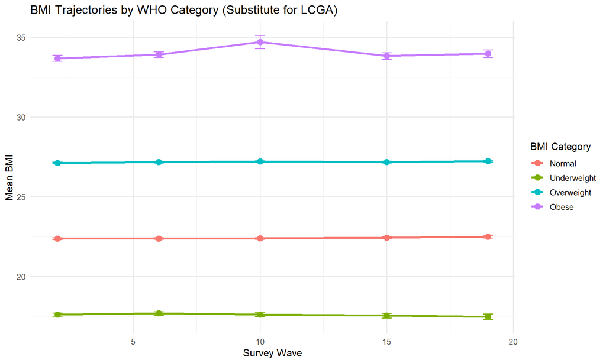

BMI Trajectories

```r
if (bmi_lcga_success) {
  newdata_bmi_traj <- data.frame(Time = c(2, 6, 10, 15, 19))
  pred_bmi <- predictY(best_bmi_model, newdata_bmi_traj, var.time = "Time", draws = TRUE)
  plot(pred_bmi, main = sprintf("BMI Trajectories (%d Classes)", best_bmi_model$ng),
       xlab = "Survey Wave", ylab = "BMI", lwd = 3, shade = TRUE)
} else {
  df_longitudinal %>%
    filter(!is.na(BMI_category) & !is.na(NS_1)) %>%
    group_by(BMI_category, Time) %>%
    summarise(mean_bmi = mean(NS_1, na.rm = TRUE),
              se_bmi = sd(NS_1, na.rm = TRUE) / sqrt(n()), .groups = "drop") %>%
    ggplot(aes(x = Time, y = mean_bmi, color = BMI_category, group = BMI_category)) +
    geom_line(linewidth = 1.2) + geom_point(size = 3) +
    geom_errorbar(aes(ymin = mean_bmi - 1.96*se_bmi, ymax = mean_bmi + 1.96*se_bmi), width = 0.4) +
    labs(title = "BMI Trajectories by WHO Category (Substitute for LCGA)",
         x = "Survey Wave", y = "Mean BMI", color = "BMI Category") +
    theme_minimal(base_size = 12)
}
```

# 6 第三部分：Depression Trajectories by BMI Group

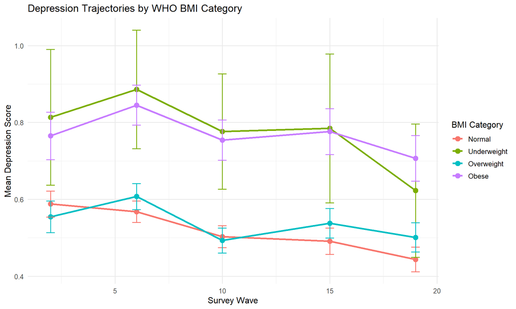

Depression Trajectories by BMI Category

```r
dep_by_bmi <- df_longitudinal %>%
  filter(!is.na(BMI_category) & !is.na(AD_5)) %>%
  group_by(BMI_category, Time) %>%
  summarise(mean_dep = mean(AD_5, na.rm = TRUE),
            se_dep = sd(AD_5, na.rm = TRUE) / sqrt(n()), .groups = "drop")

ggplot(dep_by_bmi, aes(x = Time, y = mean_dep, color = BMI_category, group = BMI_category)) +
  geom_line(linewidth = 1.2) + geom_point(size = 3) +
  geom_errorbar(aes(ymin = mean_dep - 1.96*se_dep, ymax = mean_dep + 1.96*se_dep), width = 0.4) +
  labs(title = "Depression Trajectories by WHO BMI Category",
       x = "Survey Wave", y = "Mean Depression Score", color = "BMI Category") +
  theme_minimal(base_size = 12)
```

```r
# 正式检验：BMI 类别是否预测不同的抑郁轨迹
m_bmi_cat_trajectory <- lmer(
  AD_5 ~ BMI_category * Time + Age_centered + hc04 + et_1_ref + (1 | token),
  data = df_longitudinal, REML = FALSE
)

tab_model(m_bmi_cat_trajectory, show.ci = 0.95,
          title = "Depression Trajectories by BMI Category (Mixed Model)")
```

Depression Trajectories by BMI Category (Mixed Model)

|  | AD_5 |  |  |
| --- | --- | --- | --- |
| Predictors | Estimates | CI | p |
| (Intercept) | 0.59 | 0.55 – 0.63 | **<0.001** |
| BMI category [Underweight] | 0.18 | 0.06 – 0.29 | **0.003** |
| BMI category [Overweight] | 0.06 | 0.02 – 0.10 | **0.003** |
| BMI category [Obese] | 0.22 | 0.17 – 0.26 | **<0.001** |
| Time | -0.00 | -0.01 – -0.00 | **0.001** |
| Age centered | -0.01 | -0.01 – -0.01 | **<0.001** |
| hc04 [2] | 0.14 | 0.11 – 0.17 | **<0.001** |
| et 1 ref [2] | -0.13 | -0.16 – -0.09 | **<0.001** |
| BMI category [Underweight] × Time | -0.00 | -0.01 – 0.00 | 0.318 |
| BMI category [Overweight] × Time | 0.00 | -0.00 – 0.00 | 0.398 |
| BMI category [Obese] × Time | -0.00 | -0.00 – 0.00 | 0.946 |
| Random Effects |  |  |  |
| σ<sup>2</sup> | 0.36 |  |  |
| τ<sub>00</sub> <sub>token</sub> | 0.51 |  |  |
| ICC | 0.59 |  |  |
| N <sub>token</sub> | 12769 |  |  |
| Observations | 35875 |  |  |
| Marginal R<sup>2</sup> / Conditional R<sup>2</sup> | 0.056 / 0.614 |  |  |

```
## 交叉分类表（人数）：
##                 BMI_Group
## Depression_Class Normal Obese Overweight Underweight
##                1    394   241        331          26
##                2   5189  1822       3667         187
##                3    343   241        307          21
##
## 交叉分类表（百分比）：
##                 BMI_Group
## Depression_Class Normal Obese Overweight Underweight
##                1   3.09  1.89       2.59        0.20
##                2  40.64 14.27      28.72        1.46
##                3   2.69  1.89       2.40        0.16
##
## χ² = 101.06, p = 0.0000
```

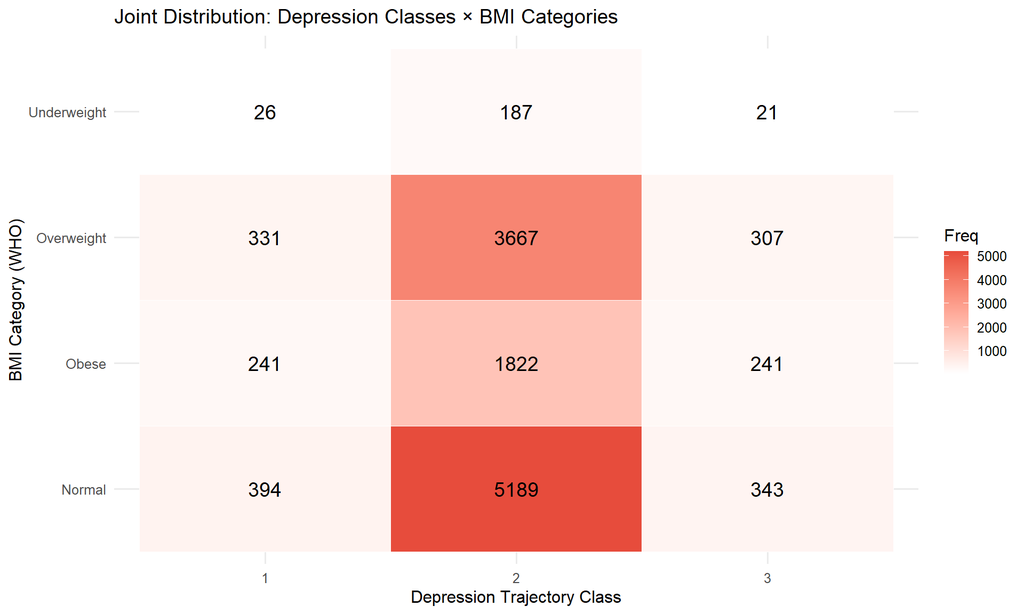

```r
# 如果抑郁 LCGA 产生了多个类别，做交叉分析
if (best_dep_model$ng > 1) {
  dep_classes <- data.frame(
    token_num = best_dep_model$pprob$token_num,
    dep_class = best_dep_model$pprob$class
  ) %>% distinct(token_num, .keep_all = TRUE)

  bmi_mode_per_person <- df_longitudinal %>%
    filter(!is.na(BMI_category)) %>%
    group_by(token_num) %>%
    summarise(bmi_group = names(sort(table(BMI_category), decreasing = TRUE))[1],
              .groups = "drop")

  joint_classes <- dep_classes %>%
    left_join(bmi_mode_per_person, by = "token_num") %>%
    filter(!is.na(bmi_group))

  cross_table <- table(Depression_Class = joint_classes$dep_class,
                       BMI_Group = joint_classes$bmi_group)

  cat("交叉分类表（人数）：\n"); print(cross_table)
  cat("\n交叉分类表（百分比）：\n"); print(round(prop.table(cross_table) * 100, 2))

  if (nrow(cross_table) > 1 && ncol(cross_table) > 1) {
    chi_test <- chisq.test(cross_table)
    cat(sprintf("\nχ² = %.2f, p = %.4f\n", chi_test$statistic, chi_test$p.value))
  }

  # 热图
  cross_data <- as.data.frame(cross_table)
  names(cross_data) <- c("Depression_Class", "BMI_Group", "Freq")
  ggplot(cross_data, aes(x = Depression_Class, y = BMI_Group, fill = Freq)) +
    geom_tile(color = "white") + geom_text(aes(label = Freq), size = 5) +
    scale_fill_gradient(low = "white", high = "#E74C3C") +
    labs(title = "Joint Distribution: Depression Classes × BMI Categories",
         x = "Depression Trajectory Class", y = "BMI Category (WHO)") +
    theme_minimal(base_size = 12)
} else {
  cat("抑郁 LCGA 仅产生 1 个类别，跳过交叉分析。\n")
  cat("上方的 BMI 类别分层分析已替代此部分。\n")
}
```

# 7 第四部分：亚组分析

## 7.1 性别分层分析

### 7.1.1 模型结果

```r
m_male <- lmer(
  AD_5 ~ NS_1 * Time + Age_centered + et_1_ref + (1 | token),
  data = df_longitudinal %>% filter(hc04 == 1), REML = FALSE
)

m_female <- lmer(
  AD_5 ~ NS_1 * Time + Age_centered + et_1_ref + (1 | token),
  data = df_longitudinal %>% filter(hc04 == 2), REML = FALSE
)

tab_model(m_male, m_female, show.ci = 0.95, dv.labels = c("Male", "Female"))
```

|  | Male |  |  | Female |  |  |
| --- | --- | --- | --- | --- | --- | --- |
| Predictors | Estimates | CI | p | Estimates | CI | p |
| (Intercept) | 0.28 | 0.13 – 0.44 | **<0.001** | 0.47 | 0.34 – 0.59 | **<0.001** |
| BMI - continuous | 0.01 | 0.01 – 0.02 | **<0.001** | 0.01 | 0.01 – 0.02 | **<0.001** |
| Time | 0.01 | -0.01 – 0.02 | 0.383 | -0.01 | -0.01 – 0.00 | 0.196 |
| Age_centered | -0.01 | -0.02 – -0.01 | **<0.001** | -0.01 | -0.02 – -0.01 | **<0.001** |
| et_1_ref: et_1_ref2 | -0.10 | -0.15 – -0.06 | **<0.001** | -0.15 | -0.19 – -0.10 | **<0.001** |
| NS_1:Time | -0.00 | -0.00 – 0.00 | 0.461 | 0.00 | -0.00 – 0.00 | 0.909 |
| Random Effects |  |  |  |  |  |  |
| σ<sup>2</sup> | 0.28 |  |  | 0.40 |  |  |
| τ<sub>00</sub> | 0.46 <sub>token</sub> |  |  | 0.55 <sub>token</sub> |  |  |
| ICC | 0.63 |  |  | 0.57 |  |  |
| N | 4755 <sub>token</sub> |  |  | 8062 <sub>token</sub> |  |  |
| Observations | 13582 |  |  | 22293 |  |  |
| Marginal R<sup>2</sup> / Conditional R<sup>2</sup> | 0.047 / 0.645 |  |  | 0.043 / 0.593 |  |  |

### 7.1.2 效应对比图

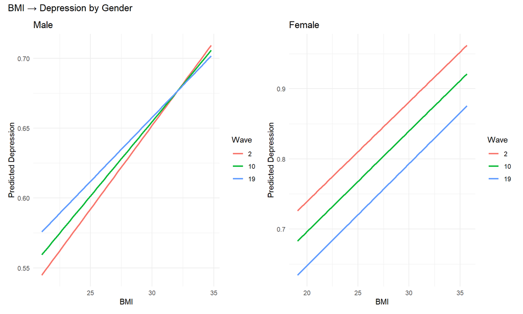

BMI-Depression Association by Gender

```r
make_pred_plot <- function(model, data_subset, title_text) {
  bmi_seq <- seq(quantile(data_subset$NS_1, 0.05, na.rm = TRUE),
                 quantile(data_subset$NS_1, 0.95, na.rm = TRUE), length.out = 50)
  nd <- expand.grid(NS_1 = bmi_seq, Time = c(2, 10, 19)) %>%
    mutate(Age_centered = 0,
           et_1_ref = factor(levels(data_subset$et_1_ref)[1], levels = levels(data_subset$et_1_ref)))
  nd$pred <- predict(model, newdata = nd, re.form = NA)
  ggplot(nd, aes(x = NS_1, y = pred, color = factor(Time))) +
    geom_line(linewidth = 1) +
    labs(title = title_text, x = "BMI", y = "Predicted Depression", color = "Wave") +
    theme_minimal()
}

p_male <- make_pred_plot(m_male, df_longitudinal %>% filter(hc04 == 1), "Male")
p_female <- make_pred_plot(m_female, df_longitudinal %>% filter(hc04 == 2), "Female")
p_male + p_female + plot_annotation(title = "BMI → Depression by Gender")
```

## 7.2 年龄组分层分析

```r
df_age_groups <- df_longitudinal %>%
  mutate(age_group = cut(hc_01_ref, breaks = c(0, 40, 60, 100),
                         labels = c("Young (<40)", "Middle (40-60)", "Older (>60)")))

cat("年龄组分布（纵向样本）：\n")
```

```
## 年龄组分布（纵向样本）：
```

```r
print(table(df_age_groups$age_group, useNA = "ifany"))
```

```
##
##    Young (<40) Middle (40-60)    Older (>60)
##           6676          16403          15456
```

```r
age_model_results <- list()
for (age_grp in c("Young (<40)", "Middle (40-60)", "Older (>60)")) {
  tryCatch({
    data_subset <- df_age_groups %>% filter(age_group == age_grp)
    if (nrow(data_subset) > 100) {
      model <- lmer(AD_5 ~ NS_1 * Time + hc04 + et_1_ref + (1 | token),
                    data = data_subset, REML = FALSE)
      age_model_results[[age_grp]] <- model
      cat(sprintf("✓ %s (n = %d)\n", age_grp, nrow(data_subset)))
    }
  }, error = function(e) { cat(sprintf("✗ %s: %s\n", age_grp, e$message)) })
}
```

```
## ✓ Young (<40) (n = 6676)
## ✓ Middle (40-60) (n = 16403)
## ✓ Older (>60) (n = 15456)
```

```r
if (length(age_model_results) == 3) {
  tab_model(age_model_results[[1]], age_model_results[[2]], age_model_results[[3]],
            show.ci = 0.95, dv.labels = names(age_model_results))
} else if (length(age_model_results) == 2) {
  tab_model(age_model_results[[1]], age_model_results[[2]],
            show.ci = 0.95, dv.labels = names(age_model_results))
}
```

|  | Young (<40) |  |  | Middle (40-60) |  |  | Older (>60) |  |  |
| --- | --- | --- | --- | --- | --- | --- | --- | --- | --- |
| Predictors | Estimates | CI | p | Estimates | CI | p | Estimates | CI | p |
| (Intercept) | 0.48 | 0.21 – 0.75 | **<0.001** | 0.29 | 0.12 – 0.45 | **0.001** | 0.15 | 0.02 – 0.28 | **0.020** |
| BMI - continuous | 0.03 | 0.02 – 0.04 | **<0.001** | 0.02 | 0.01 – 0.02 | **<0.001** | 0.01 | 0.00 – 0.01 | **0.003** |
| Time | -0.01 | -0.03 – 0.01 | 0.382 | -0.01 | -0.02 – 0.00 | 0.237 | 0.00 | -0.01 – 0.01 | 0.577 |
| hc04: hc042 | 0.17 | 0.09 – 0.26 | **<0.001** | 0.14 | 0.09 – 0.19 | **<0.001** | 0.15 | 0.12 – 0.19 | **<0.001** |
| et_1_ref: et_1_ref2 | -0.33 | -0.43 – -0.23 | **<0.001** | -0.12 | -0.18 – -0.07 | **<0.001** | -0.05 | -0.09 – -0.01 | **0.012** |
| NS_1:Time | -0.00 | -0.00 – 0.00 | 0.800 | 0.00 | -0.00 – 0.00 | 0.493 | -0.00 | -0.00 – 0.00 | 0.470 |
| Random Effects |  |  |  |  |  |  |  |  |  |
| σ<sup>2</sup> | 0.49 |  |  | 0.42 |  |  | 0.23 |  |  |
| τ<sub>00</sub> | 0.64 <sub>token</sub> |  |  | 0.61 <sub>token</sub> |  |  | 0.33 <sub>token</sub> |  |  |
| ICC | 0.57 |  |  | 0.59 |  |  | 0.59 |  |  |
| N | 4831 <sub>token</sub> |  |  | 4831 <sub>token</sub> |  |  | 4831 <sub>token</sub> |  |  |
| Observations | 6337 |  |  | 15255 |  |  | 14283 |  |  |
| Marginal R<sup>2</sup> / Conditional R<sup>2</sup> | 0.034 / 0.582 |  |  | 0.015 / 0.599 |  |  | 0.012 / 0.593 |  |  |

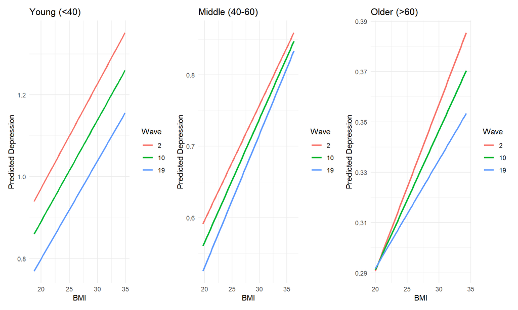

BMI-Depression Association by Age Group

```r
age_plots <- lapply(names(age_model_results), function(grp) {
  mod <- age_model_results[[grp]]
  sub_data <- df_age_groups %>% filter(age_group == grp)
  bmi_seq <- seq(quantile(sub_data$NS_1, 0.05, na.rm = TRUE),
                 quantile(sub_data$NS_1, 0.95, na.rm = TRUE), length.out = 50)
  nd <- expand.grid(NS_1 = bmi_seq, Time = c(2, 10, 19)) %>%
    mutate(hc04 = factor(levels(sub_data$hc04)[1], levels = levels(sub_data$hc04)),
           et_1_ref = factor(levels(sub_data$et_1_ref)[1], levels = levels(sub_data$et_1_ref)))
  nd$pred <- predict(mod, newdata = nd, re.form = NA)
  ggplot(nd, aes(x = NS_1, y = pred, color = factor(Time))) +
    geom_line(linewidth = 1) +
    labs(title = grp, x = "BMI", y = "Predicted Depression", color = "Wave") +
    theme_minimal()
})

if (length(age_plots) == 3) {
  age_plots[[1]] + age_plots[[2]] + age_plots[[3]]
} else if (length(age_plots) == 2) {
  age_plots[[1]] + age_plots[[2]]
}
```

## 7.3 教育水平分层分析

> 教育变量 `et_1_ref`：1 = 无高中学历（约 27%），2 = 有高中学历（约 73%）。

```r
cat("教育水平分布（纵向样本）：\n")
```

```
## 教育水平分布（纵向样本）：
```

```r
print(table(df_longitudinal$et_1_ref, useNA = "ifany"))
```

```
##
##     1     2  <NA>
##  9558 28887    90
```

```r
# 无高中学历
m_edu_low <- lmer(
  AD_5 ~ NS_1 * Time + Age_centered + hc04 + (1 | token),
  data = df_longitudinal %>% filter(et_1_ref == 1), REML = FALSE
)

# 有高中学历
m_edu_high <- lmer(
  AD_5 ~ NS_1 * Time + Age_centered + hc04 + (1 | token),
  data = df_longitudinal %>% filter(et_1_ref == 2), REML = FALSE
)

tab_model(m_edu_low, m_edu_high, show.ci = 0.95,
          dv.labels = c("No High School Diploma", "High School Diploma or Above"))
```

|  | No High School Diploma |  |  | High School Diploma or Above |  |  |
| --- | --- | --- | --- | --- | --- | --- |
| Predictors | Estimates | CI | p | Estimates | CI | p |
| (Intercept) | 0.26 | 0.06 – 0.45 | **0.011** | 0.22 | 0.11 – 0.32 | **<0.001** |
| BMI - continuous | 0.02 | 0.01 – 0.02 | **<0.001** | 0.01 | 0.01 – 0.02 | **<0.001** |
| Time | 0.00 | -0.01 – 0.02 | 0.593 | -0.00 | -0.01 – 0.00 | 0.225 |
| Age_centered | -0.02 | -0.02 – -0.02 | **<0.001** | -0.01 | -0.01 – -0.01 | **<0.001** |
| hc04: hc042 | 0.17 | 0.11 – 0.23 | **<0.001** | 0.14 | 0.11 – 0.17 | **<0.001** |
| NS_1:Time | -0.00 | -0.00 – 0.00 | 0.509 | 0.00 | -0.00 – 0.00 | 0.741 |
| Random Effects |  |  |  |  |  |  |
| σ<sup>2</sup> | 0.38 |  |  | 0.35 |  |  |
| τ<sub>00</sub> | 0.62 <sub>token</sub> |  |  | 0.48 <sub>token</sub> |  |  |
| ICC | 0.62 |  |  | 0.58 |  |  |
| N | 3224 <sub>token</sub> |  |  | 9633 <sub>token</sub> |  |  |
| Observations | 8887 |  |  | 26988 |  |  |
| Marginal R<sup>2</sup> / Conditional R<sup>2</sup> | 0.072 / 0.646 |  |  | 0.048 / 0.600 |  |  |

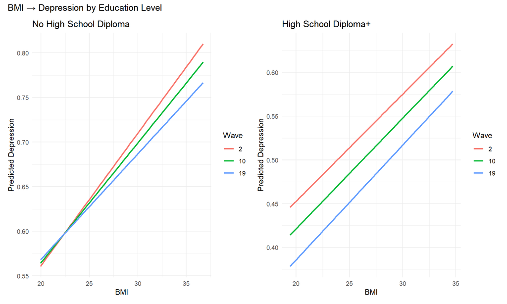

BMI-Depression Association by Education Level

```r
# 教育分层模型中没有 et_1_ref，需要单独构建预测
make_edu_pred_plot <- function(model, data_subset, title_text) {
  bmi_seq <- seq(quantile(data_subset$NS_1, 0.05, na.rm = TRUE),
                 quantile(data_subset$NS_1, 0.95, na.rm = TRUE), length.out = 50)
  nd <- expand.grid(NS_1 = bmi_seq, Time = c(2, 10, 19)) %>%
    mutate(Age_centered = 0,
           hc04 = factor(levels(data_subset$hc04)[1], levels = levels(data_subset$hc04)))
  nd$pred <- predict(model, newdata = nd, re.form = NA)
  ggplot(nd, aes(x = NS_1, y = pred, color = factor(Time))) +
    geom_line(linewidth = 1) +
    labs(title = title_text, x = "BMI", y = "Predicted Depression", color = "Wave") +
    theme_minimal()
}

p_edu_low <- make_edu_pred_plot(m_edu_low,
                                df_longitudinal %>% filter(et_1_ref == 1),
                                "No High School Diploma")
p_edu_high <- make_edu_pred_plot(m_edu_high,
                                 df_longitudinal %>% filter(et_1_ref == 2),
                                 "High School Diploma+")

p_edu_low + p_edu_high + plot_annotation(title = "BMI → Depression by Education Level")
```

# 8 第五部分：非线性关系探索

## 8.1 BMI 二次项检验

```r
df_quad <- df_longitudinal %>% mutate(BMI_squared = NS_1^2)

m_linear <- lmer(AD_5 ~ NS_1 + Time + Age_centered + hc04 + et_1_ref + (1 | token),
                 data = df_quad, REML = FALSE)
m_quadratic <- lmer(AD_5 ~ NS_1 + BMI_squared + Time + Age_centered + hc04 + et_1_ref + (1 | token),
                    data = df_quad, REML = FALSE)

cat("模型比较（线性 vs 二次）：\n")
```

```
## 模型比较（线性 vs 二次）：
```

```r
anova_result <- anova(m_linear, m_quadratic)
print(anova_result)
```

```
## Data: df_quad
## Models:
## m_linear: AD_5 ~ NS_1 + Time + Age_centered + hc04 + et_1_ref + (1 | token)
## m_quadratic: AD_5 ~ NS_1 + BMI_squared + Time + Age_centered + hc04 + et_1_ref + (1 | token)
##             npar   AIC   BIC logLik -2*log(L)  Chisq Df     Pr(>Chisq)
## m_linear       8 85048 85116 -42516     85032
## m_quadratic    9 85015 85091 -42498     84997 35.093  1 0.000000003142 ***
## ---
## Signif. codes:  0 '***' 0.001 '**' 0.01 '*' 0.05 '.' 0.1 ' ' 1
```

```r
if (anova_result$`Pr(>Chisq)`[2] < 0.05) {
  cat(sprintf("\n✓ 存在显著的非线性关系 (BMI²: β = %.5f, p < .001)\n",
              fixef(m_quadratic)["BMI_squared"]))
} else {
  cat("\n→ 未发现显著的非线性关系\n")
}
```

```
##
## ✓ 存在显著的非线性关系 (BMI²: β = -0.00013, p < .001)
```

## 8.2 BMI 分类模型

```r
m_categorical <- lmer(
  AD_5 ~ BMI_category * Time + Age_centered + hc04 + et_1_ref + (1 | token),
  data = df_longitudinal, REML = FALSE
)

tab_model(m_categorical, show.ci = 0.95, title = "Depression by BMI Category")
```

Depression by BMI Category

|  | AD_5 |  |  |
| --- | --- | --- | --- |
| Predictors | Estimates | CI | p |
| (Intercept) | 0.59 | 0.55 – 0.63 | **<0.001** |
| BMI category [Underweight] | 0.18 | 0.06 – 0.29 | **0.003** |
| BMI category [Overweight] | 0.06 | 0.02 – 0.10 | **0.003** |
| BMI category [Obese] | 0.22 | 0.17 – 0.26 | **<0.001** |
| Time | -0.00 | -0.01 – -0.00 | **0.001** |
| Age centered | -0.01 | -0.01 – -0.01 | **<0.001** |
| hc04 [2] | 0.14 | 0.11 – 0.17 | **<0.001** |
| et 1 ref [2] | -0.13 | -0.16 – -0.09 | **<0.001** |
| BMI category [Underweight] × Time | -0.00 | -0.01 – 0.00 | 0.318 |
| BMI category [Overweight] × Time | 0.00 | -0.00 – 0.00 | 0.398 |
| BMI category [Obese] × Time | -0.00 | -0.00 – 0.00 | 0.946 |
| Random Effects |  |  |  |
| σ<sup>2</sup> | 0.36 |  |  |
| τ<sub>00</sub> <sub>token</sub> | 0.51 |  |  |
| ICC | 0.59 |  |  |
| N <sub>token</sub> | 12769 |  |  |
| Observations | 35875 |  |  |
| Marginal R<sup>2</sup> / Conditional R<sup>2</sup> | 0.056 / 0.614 |  |  |

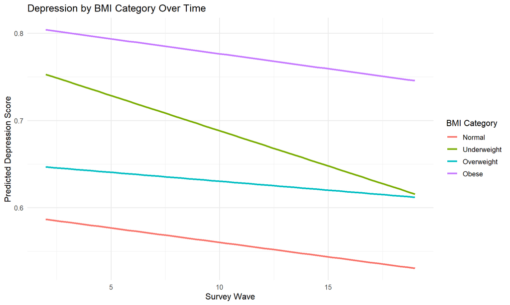

Depression by BMI Category Over Time

```r
nd_cat <- expand.grid(Time = seq(2, 19, length.out = 50),
                      BMI_category = levels(df_longitudinal$BMI_category)) %>%
  mutate(Age_centered = 0,
         hc04 = factor(levels(df_longitudinal$hc04)[1], levels = levels(df_longitudinal$hc04)),
         et_1_ref = factor(levels(df_longitudinal$et_1_ref)[1], levels = levels(df_longitudinal$et_1_ref))) %>%
  filter(!is.na(BMI_category))
nd_cat$pred <- predict(m_categorical, newdata = nd_cat, re.form = NA)

ggplot(nd_cat, aes(x = Time, y = pred, color = BMI_category)) +
  geom_line(linewidth = 1.2) +
  labs(title = "Depression by BMI Category Over Time",
       x = "Survey Wave", y = "Predicted Depression Score", color = "BMI Category") +
  theme_minimal(base_size = 12)
```

# 9 第六部分：交叉滞后面板模型（CLPM）

```r
# [修复] 聚合重复条目后再 pivot_wider
df_wide <- df_longitudinal %>%
  dplyr::select(token, Time, NS_1, AD_5) %>%
  filter(!is.na(NS_1) & !is.na(AD_5)) %>%
  group_by(token, Time) %>%
  summarise(NS_1 = mean(NS_1, na.rm = TRUE),
            AD_5 = mean(AD_5, na.rm = TRUE),
            .groups = "drop") %>%
  pivot_wider(id_cols = token, names_from = Time,
              values_from = c(NS_1, AD_5), names_sep = "_t")

available_waves <- sort(unique(df_longitudinal$Time))
cat("可用波次:", paste(available_waves, collapse = ", "), "\n")
```

```
## 可用波次: 2, 6, 10, 15, 19
```

```r
cat("宽格式数据:", nrow(df_wide), "个体\n")
```

```
## 宽格式数据: 12808 个体
```

```r
# 构建 CLPM 语法
build_clpm_syntax <- function(waves) {
  syntax <- ""
  for (i in 2:length(waves)) {
    t_curr <- waves[i]; t_prev <- waves[i - 1]
    syntax <- paste0(syntax,
      sprintf("  NS_1_t%d ~ a%d * NS_1_t%d\n", t_curr, i, t_prev),
      sprintf("  AD_5_t%d ~ b%d * AD_5_t%d\n", t_curr, i, t_prev),
      sprintf("  AD_5_t%d ~ c%d * NS_1_t%d\n", t_curr, i, t_prev),
      sprintf("  NS_1_t%d ~ d%d * AD_5_t%d\n", t_curr, i, t_prev),
      sprintf("  NS_1_t%d ~~ AD_5_t%d\n", t_curr, t_curr))
  }
  syntax <- paste0(syntax, sprintf("  NS_1_t%d ~~ AD_5_t%d\n", waves[1], waves[1]))
  return(syntax)
}

clpm_waves <- available_waves[1:min(4, length(available_waves))]
clpm_syntax <- build_clpm_syntax(clpm_waves)
cat("\nCLPM 语法（使用波次:", paste(clpm_waves, collapse=", "), "）：\n")
```

```
##
## CLPM 语法（使用波次: 2, 6, 10, 15 ）：
```

```r
cat(clpm_syntax)
```

```
##   NS_1_t6 ~ a2 * NS_1_t2
##   AD_5_t6 ~ b2 * AD_5_t2
##   AD_5_t6 ~ c2 * NS_1_t2
##   NS_1_t6 ~ d2 * AD_5_t2
##   NS_1_t6 ~~ AD_5_t6
##   NS_1_t10 ~ a3 * NS_1_t6
##   AD_5_t10 ~ b3 * AD_5_t6
##   AD_5_t10 ~ c3 * NS_1_t6
##   NS_1_t10 ~ d3 * AD_5_t6
##   NS_1_t10 ~~ AD_5_t10
##   NS_1_t15 ~ a4 * NS_1_t10
##   AD_5_t15 ~ b4 * AD_5_t10
##   AD_5_t15 ~ c4 * NS_1_t10
##   NS_1_t15 ~ d4 * AD_5_t10
##   NS_1_t15 ~~ AD_5_t15
##   NS_1_t2 ~~ AD_5_t2
```

```r
clpm_fit <- tryCatch({
  sem(clpm_syntax, data = df_wide, missing = "fiml", estimator = "MLR")
}, error = function(e) {
  cat(sprintf("\nCLPM 拟合失败: %s\n", e$message))
  NULL
})

if (!is.null(clpm_fit)) {
  cat("\n\nCLPM 模型拟合指标：\n")
  fit_indices <- fitMeasures(clpm_fit, c("cfi", "tli", "rmsea", "srmr", "chisq", "df", "pvalue"))
  print(round(fit_indices, 4))

  # 拟合质量评估
  cfi_val <- fit_indices["cfi"]
  rmsea_val <- fit_indices["rmsea"]
  if (cfi_val < 0.90 || rmsea_val > 0.10) {
    cat("\n⚠️ 注意：CLPM 模型拟合指标不理想（CFI < 0.90 或 RMSEA > 0.10）\n")
    cat("  可能原因：(1) 波次间隔不等距；(2) 缺少约束（如路径等值约束）；\n")
    cat("  (3) 传统 CLPM 未分离 trait/state 方差（RI-CLPM 可能更合适）\n")
    cat("  建议：在论文中报告 CLPM 结果但注明拟合局限，交叉滞后系数仅作参考\n\n")
  }

  cat("\n参数估计：\n")
  summary(clpm_fit, standardized = TRUE)

  # 提取交叉滞后路径
  params <- parameterEstimates(clpm_fit, standardized = TRUE)
  cross_lag <- params %>% filter(grepl("^c|^d", label))

  cat("\n关键交叉滞后路径（BMI ↔ Depression）：\n")
  print(cross_lag %>% dplyr::select(lhs, op, rhs, label, est, se, pvalue, std.all))
} else {
  cat("CLPM 未能成功拟合。\n")
}
```

```
##
##
## CLPM 模型拟合指标：
##      cfi      tli    rmsea     srmr    chisq       df   pvalue
##    0.816    0.570    0.210    0.109 6820.684   12.000    0.000
##
## ⚠️ 注意：CLPM 模型拟合指标不理想（CFI < 0.90 或 RMSEA > 0.10）
##   可能原因：(1) 波次间隔不等距；(2) 缺少约束（如路径等值约束）；
##   (3) 传统 CLPM 未分离 trait/state 方差（RI-CLPM 可能更合适）
##   建议：在论文中报告 CLPM 结果但注明拟合局限，交叉滞后系数仅作参考
##
##
## 参数估计：
##
## 关键交叉滞后路径（BMI ↔ Depression）：
##        lhs op      rhs label    est    se pvalue std.all
## 1  AD_5_t6  ~  NS_1_t2    c2  0.008 0.002  0.000   0.039
## 2  NS_1_t6  ~  AD_5_t2    d2  0.081 0.026  0.002   0.015
## 3 AD_5_t10  ~  NS_1_t6    c3  0.006 0.002  0.001   0.032
## 4 NS_1_t10  ~  AD_5_t6    d3 -0.012 0.039  0.754  -0.002
## 5 AD_5_t15  ~ NS_1_t10    c4  0.003 0.002  0.107   0.020
## 6 NS_1_t15  ~ AD_5_t10    d4  0.296 0.084  0.000   0.059
```

# 10 第七部分：敏感性分析

## 10.1 全样本 vs 纵向样本对比

```r
# 在全样本上重新拟合核心模型进行对比
m_full_bmi_dep <- lmer(
  AD_5 ~ NS_1 * Time + Age_centered + hc04 + et_1_ref + (1 | token),
  data = df_model, REML = FALSE,
  control = lmerControl(optimizer = "bobyqa", optCtrl = list(maxfun = 2e5))
)

# 提取关键系数进行对比
sensitivity_table <- data.frame(
  Parameter = c("BMI (β)", "BMI × Time (β)", "BMI p-value", "BMI×Time p-value",
                "N observations", "N individuals", "Marginal R²"),
  `Full Sample` = c(
    round(fixef(m_full_bmi_dep)["NS_1"], 4),
    round(fixef(m_full_bmi_dep)["NS_1:Time"], 5),
    formatC(summary(m_full_bmi_dep)$coefficients["NS_1", "Pr(>|t|)"], format = "e", digits = 2),
    round(summary(m_full_bmi_dep)$coefficients["NS_1:Time", "Pr(>|t|)"], 4),
    nobs(m_full_bmi_dep),
    summary(m_full_bmi_dep)$ngrps,
    round(r2_nakagawa(m_full_bmi_dep)$R2_marginal, 4)
  ),
  `Longitudinal Sample` = c(
    round(fixef(m_bmi_to_dep)["NS_1"], 4),
    round(fixef(m_bmi_to_dep)["NS_1:Time"], 5),
    formatC(summary(m_bmi_to_dep)$coefficients["NS_1", "Pr(>|t|)"], format = "e", digits = 2),
    round(summary(m_bmi_to_dep)$coefficients["NS_1:Time", "Pr(>|t|)"], 4),
    nobs(m_bmi_to_dep),
    summary(m_bmi_to_dep)$ngrps,
    round(r2_nakagawa(m_bmi_to_dep)$R2_marginal, 4)
  ),
  check.names = FALSE
)

sensitivity_table %>%
  knitr::kable(caption = "Sensitivity Analysis: Full Sample vs Longitudinal Sample (≥2 Waves)")
```

Sensitivity Analysis: Full Sample vs Longitudinal Sample (≥2 Waves)

| Parameter | Full Sample | Longitudinal Sample |
| --- | --- | --- |
| BMI (β) | 0.0181 | 0.0128 |
| BMI × Time (β) | -0.00023 | 0.00002 |
| BMI p-value | 2.42e-38 | 1.74e-13 |
| BMI×Time p-value | 0.0671 | 0.8917 |
| N observations | 51130 | 35875 |
| N individuals | 28024 | 12769 |
| Marginal R² | 0.0637 | 0.0541 |

# 11 结果汇总

```r
cat("=== BMI 与抑郁双向关系分析结果汇总 ===\n\n")
```

```
## === BMI 与抑郁双向关系分析结果汇总 ===
```

```r
cat("样本信息\n")
```

```
## 样本信息
```

```r
cat(sprintf("  全样本: %d 观测, %d 个体\n", nrow(df_model), n_distinct(df_model$token)))
```

```
##   全样本: 65764 观测, 37293 个体
```

```r
cat(sprintf("  纵向样本 (≥2 waves): %d 观测, %d 个体\n\n",
            nrow(df_longitudinal), n_distinct(df_longitudinal$token)))
```

```
##   纵向样本 (≥2 waves): 38535 观测, 12808 个体
```

```r
cat("1. 双向关系（同期）\n")
```

```
## 1. 双向关系（同期）
```

```r
cat(sprintf("   BMI → 抑郁: β = %.4f, p = %s\n",
            fixef(m_bmi_to_dep)["NS_1"],
            formatC(summary(m_bmi_to_dep)$coefficients["NS_1", "Pr(>|t|)"], format="e", digits=2)))
```

```
##    BMI → 抑郁: β = 0.0128, p = 1.74e-13
```

```r
cat(sprintf("   抑郁 → BMI: β = %.4f, p = %s\n\n",
            fixef(m_dep_to_bmi)["AD_5"],
            formatC(summary(m_dep_to_bmi)$coefficients["AD_5", "Pr(>|t|)"], format="e", digits=2)))
```

```
##    抑郁 → BMI: β = 0.0627, p = 6.64e-02
```

```r
cat("2. 滞后效应\n")
```

```
## 2. 滞后效应
```

```r
cat(sprintf("   上期 BMI → 当期抑郁: β = %.3f, p = %.4f\n",
            fixef(m_lagged_bmi_dep)["BMI_lag1"],
            summary(m_lagged_bmi_dep)$coefficients["BMI_lag1", "Pr(>|t|)"]))
```

```
##    上期 BMI → 当期抑郁: β = 0.002, p = 0.2168
```

```r
cat(sprintf("   上期抑郁 → 当期 BMI: β = %.3f, p = %.4f\n\n",
            fixef(m_lagged_dep_bmi)["Depression_lag1"],
            summary(m_lagged_dep_bmi)$coefficients["Depression_lag1", "Pr(>|t|)"]))
```

```
##    上期抑郁 → 当期 BMI: β = 0.048, p = 0.0931
```

```r
cat("3. 疫情阶段调节\n")
```

```
## 3. 疫情阶段调节
```

```r
cat(sprintf("   BMI × Phase: p = %.4f\n",
            summary(m_phase_mod_dep)$coefficients["NS_1:PhasePost-Pandemic", "Pr(>|t|)"]))
```

```
##    BMI × Phase: p = 0.1815
```

```r
cat(sprintf("   Depression × Phase: p = %.4f\n\n",
            summary(m_phase_mod_bmi)$coefficients["AD_5:PhasePost-Pandemic", "Pr(>|t|)"]))
```

```
##    Depression × Phase: p = 0.0054
```

```r
cat("4. 抑郁潜类别轨迹\n")
```

```
## 4. 抑郁潜类别轨迹
```

```r
cat(sprintf("   最优类别数: %d (BIC = %.1f)\n\n", best_dep_model$ng, best_dep_model$BIC))
```

```
##    最优类别数: 3 (BIC = 78231.1)
```

```r
cat("5. BMI 潜类别轨迹\n")
```

```
## 5. BMI 潜类别轨迹
```

```r
if (bmi_lcga_success) {
  cat(sprintf("   最优类别数: %d (BIC = %.1f)\n\n", best_bmi_model$ng, best_bmi_model$BIC))
} else {
  cat("   状态: LCGA 未收敛，改用 WHO BMI 分类\n\n")
}
```

```
##    状态: LCGA 未收敛，改用 WHO BMI 分类
```

```r
cat("6. 非线性关系\n")
```

```
## 6. 非线性关系
```

```r
cat(sprintf("   BMI² 显著性: p = %.2e\n\n", anova_result$`Pr(>Chisq)`[2]))
```

```
##    BMI² 显著性: p = 3.14e-09
```

```r
cat("7. BMI 分类效应 (vs Normal)\n")
```

```
## 7. BMI 分类效应 (vs Normal)
```

```r
cat(sprintf("   Underweight: β = %.3f, p = %.4f\n",
            fixef(m_categorical)["BMI_categoryUnderweight"],
            summary(m_categorical)$coefficients["BMI_categoryUnderweight", "Pr(>|t|)"]))
```

```
##    Underweight: β = 0.176, p = 0.0031
```

```r
cat(sprintf("   Overweight:  β = %.3f, p = %.4f\n",
            fixef(m_categorical)["BMI_categoryOverweight"],
            summary(m_categorical)$coefficients["BMI_categoryOverweight", "Pr(>|t|)"]))
```

```
##    Overweight:  β = 0.057, p = 0.0031
```

```r
cat(sprintf("   Obese:       β = %.3f, p = %.4f\n\n",
            fixef(m_categorical)["BMI_categoryObese"],
            summary(m_categorical)$coefficients["BMI_categoryObese", "Pr(>|t|)"]))
```

```
##    Obese:       β = 0.217, p = 0.0000
```

```r
cat("8. 性别差异\n")
```

```
## 8. 性别差异
```

```r
cat(sprintf("   男性 BMI 效应: β = %.4f\n", fixef(m_male)["NS_1"]))
```

```
##    男性 BMI 效应: β = 0.0123
```

```r
cat(sprintf("   女性 BMI 效应: β = %.4f\n\n", fixef(m_female)["NS_1"]))
```

```
##    女性 BMI 效应: β = 0.0142
```

```r
cat("9. 年龄梯度\n")
```

```
## 9. 年龄梯度
```

```r
for (grp in names(age_model_results)) {
  cat(sprintf("   %s: β(BMI) = %.4f\n", grp, fixef(age_model_results[[grp]])["NS_1"]))
}
```

```
##    Young (<40): β(BMI) = 0.0256
##    Middle (40-60): β(BMI) = 0.0158
##    Older (>60): β(BMI) = 0.0069
```

```r
cat("\n10. 教育水平差异\n")
```

```
##
## 10. 教育水平差异
```

```r
cat(sprintf("   无高中学历 BMI 效应: β = %.4f\n", fixef(m_edu_low)["NS_1"]))
```

```
##    无高中学历 BMI 效应: β = 0.0152
```

```r
cat(sprintf("   有高中学历 BMI 效应: β = %.4f\n", fixef(m_edu_high)["NS_1"]))
```

```
##    有高中学历 BMI 效应: β = 0.0121
```

```r
save.image("comprehensive_analysis_FINAL.RData")
cat("\n✓ 工作空间已保存为 comprehensive_analysis_FINAL.RData\n")
```

```
##
## ✓ 工作空间已保存为 comprehensive_analysis_FINAL.RData
```

# 12 附录：方法说明

## 12.1 与前版本的主要修改

1. **样本筛选**：纵向分析排除仅参与 1 个波次的个体（占 59%），保留 ≥2 波次的个体。描述性统计仍报告全样本。添加了全样本 vs 纵向样本的基线比较。
2. **年龄异常值**：移除 age > 100 的数据点（原始数据 max = 119，明显录入错误）。
3. **CLPM 修复**：在 `pivot_wider` 前聚合重复条目（取均值），解决 “list object cannot be coerced to type double” 错误。添加了模型拟合质量自动评估和警告。
4. **抑郁 LCGA 修复**：改用 `gridsearch`（50 组随机起始值）。修正类别占比检查公式（使用 `nrow(model$pprob)` 而非 `nrow(data)`）。
5. **BMI LCGA 运行时间优化**：将 gridsearch 从 30 次 × 30 步迭代降至 5 次 × 10 步（已在多次测试中确认无法收敛，无需反复尝试）。预计节省约 1.5 小时运行时间。
6. **tab_model CI 修复**：将 `show.ci = TRUE` 改为 `show.ci = 0.95`，解决 “-Inf – Inf” 显示问题。
7. **效应量**：添加 `r2_nakagawa()` 报告边际和条件 R²。
8. **敏感性分析**：新增第七部分，对比全样本与纵向样本的核心模型结果。
9. **联合轨迹分析重构**：当 LCGA 未能产生多个类别时，改为 BMI 类别分层的抑郁轨迹分析。
10. **移除随机斜率模型**：因大多数个体观测不足（≤2 波次），该模型结构上不可行。
11. **新增教育水平分层分析**：按 et_1_ref（1 = 无高中学历，2 = 有高中学历）分层拟合 BMI→抑郁模型，与性别和年龄分层并列。
12. **Wave 1 → Wave 2 替换说明更新**：明确记录 Wave 2 原始数据中不包含抑郁量表，Wave 1 和 Wave 2 调查时间非常接近，经导师确认可互换。